# An R Markdown program to analyse responses to a Discrete Choice Experiment (DCE) survey exploring the online help seeking preferences of socially anxious young people

Results Summary

Matthew P Hamilton<sup>1,✉</sup>

27 October 2022

<sup>1</sup> Orygen, Parkville, Australia

<sup>✉</sup> Correspondence: Matthew P Hamilton <matthew.hamilton@orygen.org.au>

Copyright (C) 2022 Orygen

This program is free software: you can redistribute it and/or modify it under the terms of the GNU General Public License as published by the Free Software Foundation, either version 3 of the License, or (at your option) any later version.

This program is distributed in the hope that it will be useful, but WITHOUT ANY WARRANTY; without even the implied warranty of MERCHANTABILITY or FITNESS FOR A PARTICULAR PURPOSE. See the GNU General Public License for more details.

You should have received a copy of the GNU General Public License along with this program. If not, see https://www.gnu.org/licenses/.

Suggested citation: “Matthew Hamilton (2022). dce_sa_analysis: An R Markdown program to analyse responses to a Discrete Choice Experiment (DCE) survey exploring online help seeking in socially anxious young people. Zenodo. https://doi.org/10.5281/zenodo.7223286. Version 0.0.9.1”

```r
make_mdl_smry <- function(model_mdl,
                          return_1L_chr = "coefficients"){
  smry_ls <- summary(model_mdl)
  if("gmnl" %in% class(model_mdl)#startsWith(deparse(smry_ls$call)[1],"gmnl")
     ){
    smry_ls <- gmnl::getSummary.gmnl(model_mdl)
    coef_mat <- smry_ls$coef
      perf_tb <- smry_ls$sumstat %>% purrr::discard(is.na) %>% as.data.frame() %>% tibble::rownames_to_column("Statistic") %>%
      tibble::as_tibble() %>% dplyr::rename(Value = ".")
    p_var_nm_1L_chr <- "p"
  }else{
  coef_mat <- smry_ls$CoefTable
  perf_tb <- tibble::tibble(Statistic = c("logLik","AIC", "BIC","N"),
                            Value = c(smry_ls$logLik,AIC(model_mdl),BIC(model_mdl),smry_ls$freq %>% sum()))
  p_var_nm_1L_chr <-"Pr(>|z|)"
  }
  call_1L_chr <- smry_ls$call %>% deparse() %>% paste0(collapse = "") %>% stringr::str_squish()
  coef_tb <- coef_mat %>%  as.data.frame() %>% tibble::rownames_to_column("Parameter") %>%
      tibble::as_tibble() %>% dplyr::mutate(sign = cut(!!rlang::sym(p_var_nm_1L_chr), breaks = c(-Inf, 0.001, 0.01, 0.05, 0.1,Inf),
                                                       labels = c("***", "**", "*", ".","n.s."), right = FALSE))
  if(return_1L_chr == "coefficients")
    return_xx <- coef_tb
  if(return_1L_chr == "performance")
    return_xx <- perf_tb %>%
    dplyr::filter(!is.na(Value))
  if(return_1L_chr == "call")
    return_xx <- call_1L_chr
  return(return_xx)
}
```

# 1 Data processing

The raw dataset, that included records for each time any participant began viewing the online survey had 901 records.

When we dropped all records for which there were zero responses to the choice card questions, the number of records was 254.

A total of 63 cases had at lease one red flag assigned to them as a result of data integrity checks.

Table 1.1: Frequency of red flags from data integrity checks

| Number of Red Flags | Frequency |
| --- | --- |
| 0 | 191 |
| 1 | 35 |
| 2 | 15 |
| 3 | 10 |
| 4 | 3 |

Of the 107 red flags assigned to these cases, 21 were added from the qualitative assessment of participant free text responses, with the balance being flags generated by automated checks of country of origin, inconsistencies between age and date of birth data, email addresses with five or greater consecutive numeric digits, duplicate free text entries across cases and survey completion times of under five minutes.

Table 1.2: Types of red flags

| Outcome | N |
| --- | --- |
| red_flag_country_lgl | 15 |
| red_flag_reported_age_lgl | 36 |
| red_flag_email_lgl | 19 |
| red_flag_duplicate_txt_var1_lgl | 7 |
| red_flag_qltv_ax_lgl | 21 |
| red_flag_attempt_dur_lgl | 9 |
| red_flag_count_int | 107 |

In 36 cases the red flags generated by automated assessments were not in conflict with qualitative assessment (ie the qualitative assessment either also assigned a red flag or did not assign a green flag). These confirmed red flagged records were excluded along with an additional 2 records that were red flagged by the qualitative assessment but which had no automatically generated red flags. In 25 cases, red-flags added by the automated assessment were in conflict with green flags added by the qualitative assessment - these records were retained. In total, the qualitative assessment assigned a total of 210 green flags to confirm records for inclusion.

Table 1.3: Qualitative and automated assessment summary

| Outcome | N |
| --- | --- |
| over_rf_threshold_lgl | 63 |
| green_flag_qltv_ax_lgl | 210 |
| qltv_force_in_lgl | 25 |
| qltv_force_out_lgl | 2 |
| exluded_by_alg_lgl | 36 |

After dropping records arising from the data integrity checks, 216 records remained.

When these records were combined with the choice cards dataset and that merged dataset reshaped to long format (each case being a unique combination of the 3 alternatives for each of 15 choice situations presented to each individual participant) the number of records expanded to 9720.

# 2 Descriptives

## 2.1 Participant characteristics

Table 2.1: Participant Characteristics

| Concept | Measure | n=216 | Units |
| --- | --- | --- | --- |
| Age | Mean (SD) | 19.745 (3.144) |  |
| Age | Median | 19 |  |
| Age | Minimum - Maximum | 15 - 25 |  |
| Age | IQR (CV) | 6 (0.159) |  |
| Age | Missing | 0 (0.0%) |  |
| Age | Aged 20-25 | 107 (49.5%) |  |
| Age | Aged 15-19 | 109 (50.5%) |  |
| Age | Missing | 0 (0.0%) |  |
| Gender | Female | 100 (46.3%) |  |
| Gender | Male | 104 (48.1%) |  |
| Gender | Other | 8 ( 3.7%) |  |
| Gender | Prefer_NTS | 4 ( 1.9%) |  |
| Gender | Missing | 0 (0.0%) |  |
| SIAS | Mean (SD) | 48.903 (14.199) |  |
| SIAS | Median | 50 |  |
| SIAS | Minimum - Maximum | 10 - 77 |  |
| SIAS | IQR (CV) | 18 (0.29) |  |
| SIAS | Missing | 0 (0.0%) |  |
| SIAS | Normal_Range | 29 (13.4%) |  |
| SIAS | Social_Phobia | 32 (14.8%) |  |
| SIAS | Social_Anxiety | 155 (71.8%) |  |
| SIAS | Missing | 0 (0.0%) |  |
| Area disadvantage | SEIFA Quartile 1 | 25 (11.7%) |  |
| Area disadvantage | SEIFA Quartile 2 | 50 (23.4%) |  |
| Area disadvantage | SEIFA Quartile 3 | 53 (24.8%) |  |
| Area disadvantage | SEIFA Quartile 4 | 86 (40.2%) |  |
| Area disadvantage | Missing | 2 (0.9%) |  |
| Urbanicity | Major Urban | 173 (80.5%) |  |
| Urbanicity | Other Urban | 1 ( 0.5%) |  |
| Urbanicity | Rural Balance | 41 (19.1%) |  |
| Urbanicity | Missing | 1 (0.5%) |  |
| Urbanicity | Resides in a rural or remote area | 42 (19.4%) |  |
| Urbanicity | Resides in an urban area | 174 (80.6%) |  |
| Urbanicity | Missing | 0 (0.0%) |  |
| Jurisdiction | Australian Capital Territ | 5 ( 2.3%) |  |
| Jurisdiction | New South Wales | 76 (35.3%) |  |
| Jurisdiction | Queensland | 22 (10.2%) |  |
| Jurisdiction | South Australia | 18 ( 8.4%) |  |
| Jurisdiction | Tasmania | 5 ( 2.3%) |  |
| Jurisdiction | Victoria | 73 (34.0%) |  |
| Jurisdiction | Western Australia | 16 ( 7.4%) |  |
| Jurisdiction | Missing | 1 (0.5%) |  |
| Pilot participant | Responded to public advertisement | 183 (85.1%) |  |
| Pilot participant | Entourage pilot programme participant | 32 (14.9%) |  |
| Pilot participant | Missing | 1 (0.5%) |  |
| Incomplete choice tasks | Mean (SD) | 0 (0) |  |
| Incomplete choice tasks | Median | 0 |  |
| Incomplete choice tasks | Minimum - Maximum | 0 - 0 |  |
| Incomplete choice tasks | IQR (CV) | 0 (-) |  |
| Incomplete choice tasks | Missing | 0 (0.0%) |  |
| Incomplete choice tasks | Completed all choice tasks | 216 (100.0%) |  |
| Incomplete choice tasks | Missing | 0 (0.0%) |  |
| Time taken | Mean (SD) | 2083.676 (7053.325) | seconds |
| Time taken | Median | 845.5 | seconds |
| Time taken | Minimum - Maximum | 167 - 63340 | seconds |
| Time taken | IQR (CV) | 729.5 (3.385) | seconds |
| Time taken | Missing | 0 (0.0%) |  |
| Time taken | Took at least ten minutes to complete survey | 150 (69.4%) |  |
| Time taken | Completed survey in under ten minutes | 66 (30.6%) |  |
| Time taken | Missing | 0 (0.0%) |  |

## 2.2 Representativeness of sample

Table 2.2: Sample age proportions compared to official population estimates

| Age range | n | Sample (per-cent) | CI_95_Lower | CI_95_Upper | Population (per-cent) | p | p.signif |
| --- | --- | --- | --- | --- | --- | --- | --- |
| 15-19 | 109 | 50.46296 | 43.59770 | 57.31535 | 41.39885 | 0.0085141 | ** |
| 20-25 | 107 | 49.53704 | 42.68465 | 56.40230 | 58.60115 | 0.0085141 | ** |

Table 2.3: Sample resident jurisdictions proportions compared to age and sex based official population estimates

Jurisdiction

n

Sample (per-cent)

CI_95_Lower

CI_95_Upper

Population (per-cent)

p

p.signif

Australian Capital Territory

5

2.325581

0.759324

5.343395

2.014026

0.6267139

ns

New South Wales

76

35.348837

28.968538

42.139445

31.420678

0.2125593

ns

Northern Territory

0

0.000000

0.000000

1.701123

1.047619

0.1811498

ns

Queensland

22

10.232558

6.524559

15.081852

20.255360

0.0001197

***

South Australia

18

8.372093

5.037320

12.908800

6.764072

0.3403071

ns

Tasmania

5

2.325581

0.759324

5.343395

2.030695

0.6292975

ns

Victoria

73

33.953488

27.652273

40.704276

26.417747

0.0162080

Western Australia

16

7.441860

4.313300

11.803925

10.036652

0.2550859

ns

Table 2.4: Sample area disadvantage proportions compared to expected proportions

| SEIFA Disadvantage Quartile | n | Sample (per-cent) | CI_95_Lower | CI_95_Upper | Population (per-cent) | p | p.signif |
| --- | --- | --- | --- | --- | --- | --- | --- |
| SEIFA Quartile 1 | 25 | 11.68224 | 7.704559 | 16.76083 | 25 | 0.0000017 | **** |
| SEIFA Quartile 2 | 50 | 23.36449 | 17.866690 | 29.61600 | 25 | 0.6359316 | ns |
| SEIFA Quartile 3 | 53 | 24.76636 | 19.135861 | 31.11021 | 25 | 1.0000000 | ns |
| SEIFA Quartile 4 | 86 | 40.18692 | 33.561812 | 47.08784 | 25 | 0.0000011 | **** |

Table 2.5: Sample urbanicity proportions compared to age and sex based official population estimates

| Resides in urban area | n | Sample (per-cent) | CI_95_Lower | CI_95_Upper | Population (per-cent) | p | p.signif |
| --- | --- | --- | --- | --- | --- | --- | --- |
| FALSE | 42 | 19.44444 | 14.38789 | 25.36037 | 8.483811 | 5e-07 | **** |
| TRUE | 174 | 80.55556 | 74.63963 | 85.61211 | 91.296643 | 8e-07 | **** |

## Choice responses

### 2.2.1 Outcomes Attribute

Table 2.6: Outcomes attribute choice responses

| Outcomes | Freq |
| --- | --- |
| Addresses current symptoms | 680 |
| Addresses current symptoms and provides knowledge and skills to manage future situations | 905 |
| Provides knowledge and skills to manage future situations | 962 |

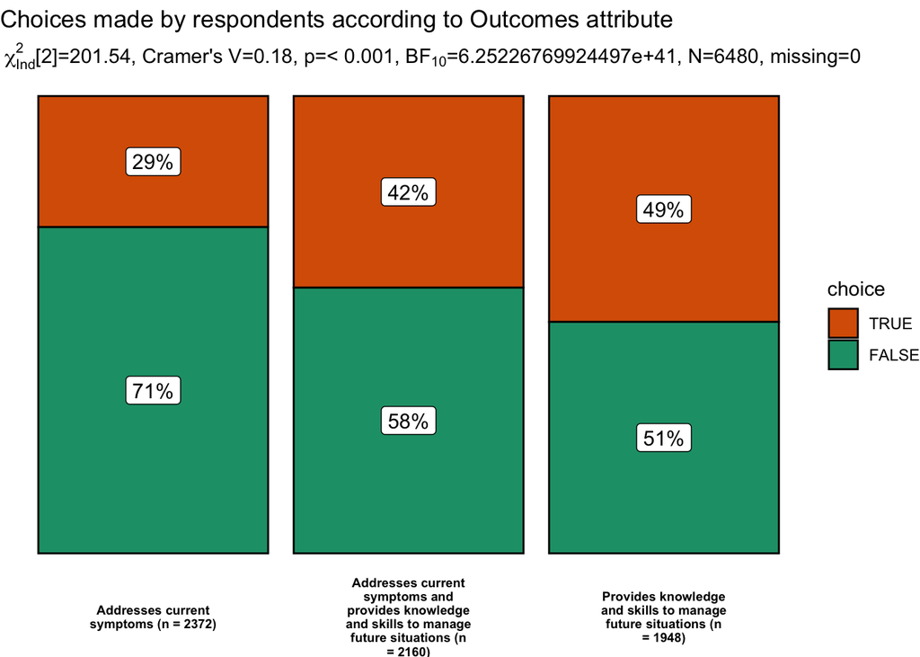

Figure 2.1: Outcomes attribute

### 2.2.2 Information sharing Attribute

Table 2.7: Information sharing attribute choice responses

| Information_sharing | Freq |
| --- | --- |
| Information is shared with your treating clinician based on settings you control | 1048 |
| Information is shared with your treating clinician in accordance with app policy | 510 |
| No information is shared with your treating clinician | 989 |

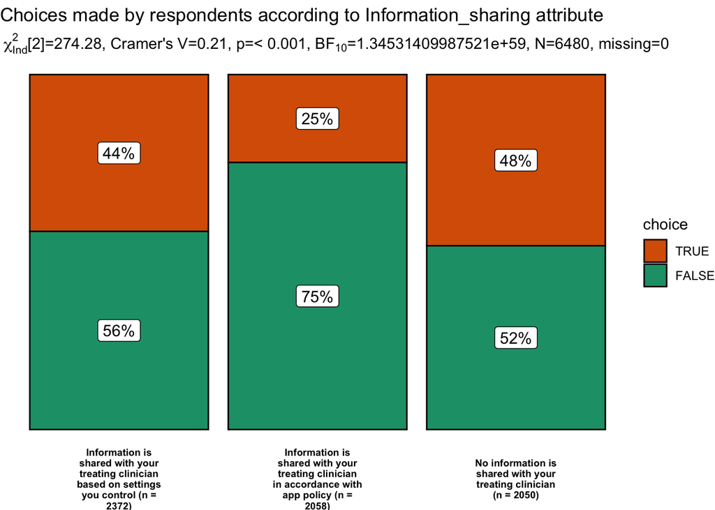

Figure 2.2: Information sharing attribute

### 2.2.3 Social Attribute

Table 2.8: Social attribute choice responses

| Social | Freq |
| --- | --- |
| Discussions with other app users moderated by both trained peers and mental health clinicians | 562 |
| Discussions with other app users moderated by mental health clinicians | 429 |
| Discussions with other app users moderated by trained peers | 472 |
| No discussions with other app users | 662 |
| Unmoderated discussions with other app users | 422 |

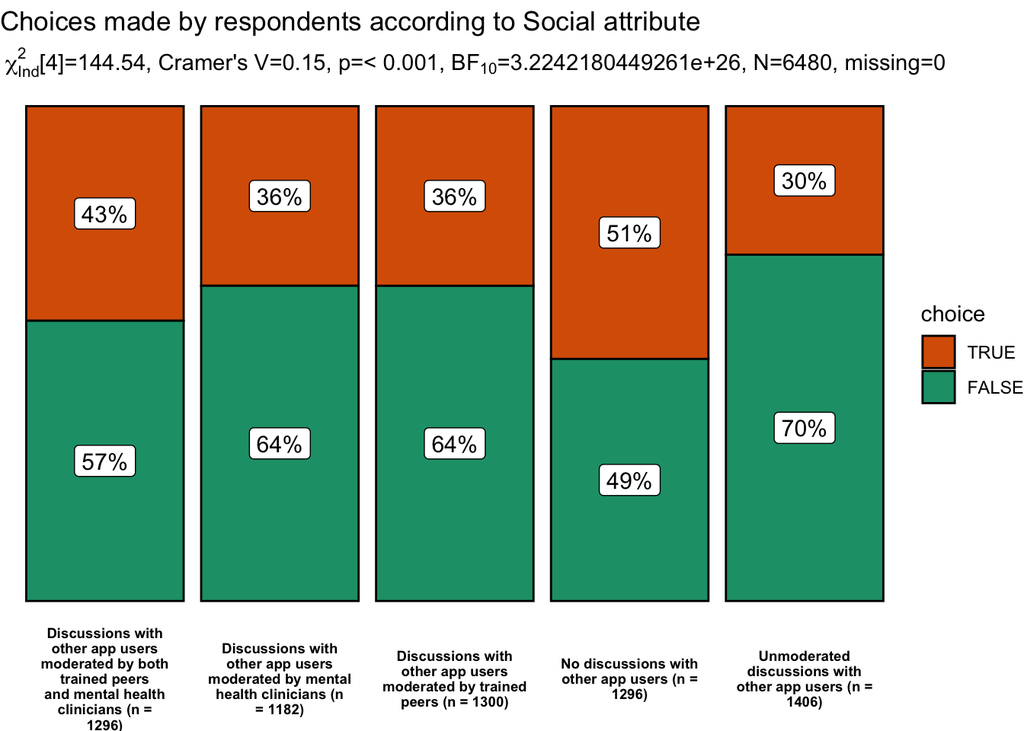

Figure 2.3: Social attribute

### 2.2.4 Endorsers Attribute

Table 2.9: Endorsers attribute choice responses

| Endorsers | Freq |
| --- | --- |
| App has no endorsers | 773 |
| App is endorsed by respected non experts | 754 |
| App is endorsed by youth mental health experts | 1020 |

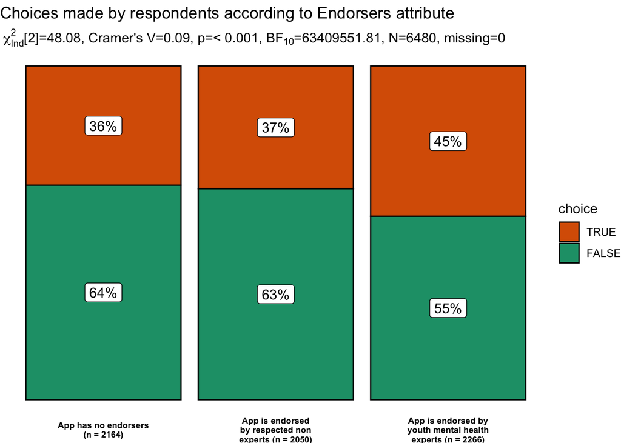

Figure 2.4: Endorsers attribute

### 2.2.5 Cost Attribute

Table 2.10: Cost attribute choice responses

| Cost | Freq |
| --- | --- |
| 0 | 1513 |
| 5 | 515 |
| 15 | 132 |
| 30 | 133 |
| 60 | 254 |

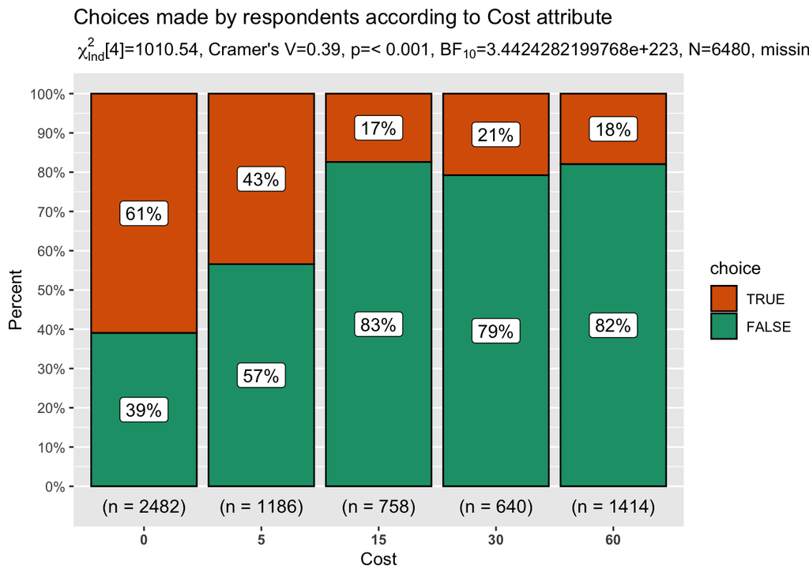

Figure 2.5: Cost attribute

### 2.2.6 Opt out alternative

Table 2.11: Opt out alternative responses

| opt_out | Freq |
| --- | --- |
| 0 | 2547 |
| 1 | 693 |

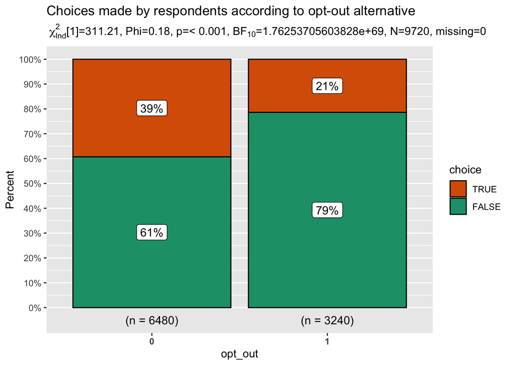

Figure 2.6: Opt out alternativee

# 3 Models

## 3.1 Models of how social anxiety app attributes shape the choice behaviour of young people

Table 3.1: Multinomial Logit Model (estimated with gmnl package)

| Parameter | est | se | stat | p | lwr | upr | sign |
| --- | --- | --- | --- | --- | --- | --- | --- |
| opt_out | -0.9159175 | 0.0978442 | -9.3609823 | 0.0000000 | -0.7241465 | -1.1076885 | *** |
| Outcomes_curr_sym | -0.3001924 | 0.0683170 | -4.3941068 | 0.0000111 | -0.1662934 | -0.4340913 | *** |
| Outcomes_curr_sym_future_sit | 0.2321426 | 0.0681290 | 3.4073955 | 0.0006559 | 0.3656730 | 0.0986121 | *** |
| Information_sharing_app_policy | -0.0699129 | 0.0826282 | -0.8461143 | 0.3974890 | 0.0920354 | -0.2318611 | n.s. |
| Information_sharing_user_settings | 0.2489098 | 0.0633325 | 3.9302048 | 0.0000849 | 0.3730393 | 0.1247803 | *** |
| Social_unmod_disc | -0.2723511 | 0.0941473 | -2.8928174 | 0.0038180 | -0.0878257 | -0.4568765 | ** |
| Social_trained_peer_mod | 0.3063949 | 0.0945210 | 3.2415532 | 0.0011888 | 0.4916527 | 0.1211371 | ** |
| Social_clinician_mod | 0.2900678 | 0.0907857 | 3.1950828 | 0.0013979 | 0.4680045 | 0.1121311 | ** |
| Social_peer_clinician_mod | 0.5122196 | 0.0905456 | 5.6570368 | 0.0000000 | 0.6896857 | 0.3347536 | *** |
| Endorsers_non_expert | 0.2496434 | 0.0666382 | 3.7462535 | 0.0001795 | 0.3802518 | 0.1190350 | *** |
| Endorsers_expert | 0.6956661 | 0.0627859 | 11.0799731 | 0.0000000 | 0.8187242 | 0.5726080 | *** |
| Cost | -0.0434838 | 0.0019235 | -22.6066445 | 0.0000000 | -0.0397139 | -0.0472538 | *** |

Note:  
Signif. codes: 0 ‘**’ 0.001 ‘**’ 0.01 ‘’ 0.05 ‘.’ 0.1 ‘ ’ 1

Table 3.2: Performance of Multinomial Logit Model (estimated with gmnl package)

| Statistic | Value |
| --- | --- |
| logLik | -2845.168 |
| AIC | 5714.337 |
| BIC | 5787.337 |
| N | 3240.000 |

Table 3.3: Multinomial Logit Model (estimated with mlogit package)

| Parameter | Estimate | Std. Error | z-value | Pr(>\|z\|) | sign |
| --- | --- | --- | --- | --- | --- |
| opt_out | -0.9159175 | 0.0978442 | -9.3609822 | 0.0000000 | *** |
| Outcomes_curr_sym | -0.3001924 | 0.0683170 | -4.3941068 | 0.0000111 | *** |
| Outcomes_curr_sym_future_sit | 0.2321426 | 0.0681290 | 3.4073955 | 0.0006559 | *** |
| Information_sharing_app_policy | -0.0699129 | 0.0826282 | -0.8461143 | 0.3974890 | n.s. |
| Information_sharing_user_settings | 0.2489098 | 0.0633325 | 3.9302048 | 0.0000849 | *** |
| Social_unmod_disc | -0.2723511 | 0.0941473 | -2.8928174 | 0.0038180 | ** |
| Social_trained_peer_mod | 0.3063949 | 0.0945210 | 3.2415532 | 0.0011888 | ** |
| Social_clinician_mod | 0.2900678 | 0.0907857 | 3.1950828 | 0.0013979 | ** |
| Social_peer_clinician_mod | 0.5122196 | 0.0905456 | 5.6570368 | 0.0000000 | *** |
| Endorsers_non_expert | 0.2496434 | 0.0666382 | 3.7462535 | 0.0001795 | *** |
| Endorsers_expert | 0.6956661 | 0.0627859 | 11.0799731 | 0.0000000 | *** |
| Cost | -0.0434838 | 0.0019235 | -22.6066445 | 0.0000000 | *** |

Note:  
Signif. codes: 0 ‘**’ 0.001 ‘**’ 0.01 ‘’ 0.05 ‘.’ 0.1 ‘ ’ 1

Table 3.4: Performance of Multinomial Logit Model (estimated with mlogit package)

| Statistic | Value |
| --- | --- |
| logLik | -2845.168 |
| AIC | 5714.337 |
| N | 3240.000 |

## 3.2 Models of the heterogeneity of young people’s preferences for social anxiety apps

Table 3.5: Mixed Logit Model (estimated with gmnl package)

Parameter

est

se

stat

p

lwr

upr

sign

opt_out

-1.7285178

0.2047389

-8.4425487

0.0000000

-1.3272370

-2.1297985

***

Outcomes_curr_sym

-0.5394218

0.1104277

-4.8848411

0.0000010

-0.3229875

-0.7558562

***

Outcomes_curr_sym_future_sit

0.1174913

0.1214279

0.9675807

0.3332538

0.3554856

-0.1205030

n.s.

Information_sharing_app_policy

-0.2866755

0.1616776

-1.7731314

0.0762069

0.0302066

-0.6035577

.

Information_sharing_user_settings

0.4085120

0.1179745

3.4627147

0.0005348

0.6397378

0.1772863

***

Social_unmod_disc

-0.4300076

0.1562048

-2.7528444

0.0059080

-0.1238518

-0.7361635

Social_trained_peer_mod

0.2216966

0.1572669

1.4096842

0.1586330

0.5299341

-0.0865408

n.s.

Social_clinician_mod

0.3404081

0.1476301

2.3058175

0.0211208

0.6297578

0.0510584

Social_peer_clinician_mod

0.5110139

0.1487906

3.4344503

0.0005938

0.8026381

0.2193897

***

Endorsers_non_expert

0.2969256

0.0978352

3.0349564

0.0024057

0.4886791

0.1051721

Endorsers_expert

1.0468801

0.1127855

9.2820477

0.0000000

1.2679356

0.8258247

***

Cost

-0.0943227

0.0069617

-13.5488606

0.0000000

-0.0806781

-0.1079673

***

sd.Cost.Cost

-2.6959964

0.2503604

-10.7684637

0.0000000

-2.2052991

-3.1866937

***

sd.Cost.Outcomes_curr_sym

-0.6632696

0.1354690

-4.8960969

0.0000010

-0.3977551

-0.9287840

***

sd.Cost.Outcomes_curr_sym_future_sit

-1.1360923

0.1495849

-7.5949668

0.0000000

-0.8429113

-1.4292734

***

sd.Cost.Information_sharing_app_policy

-1.2233279

0.1917177

-6.3808824

0.0000000

-0.8475682

-1.5990876

***

sd.Cost.Information_sharing_user_settings

-0.8585465

0.1396228

-6.1490403

0.0000000

-0.5848908

-1.1322023

***

sd.Cost.Social_unmod_disc

-0.0563617

0.1939019

-0.2906712

0.7713028

0.3236791

-0.4364025

n.s.

sd.Cost.Social_trained_peer_mod

-0.7083046

0.1777734

-3.9843122

0.0000677

-0.3598752

-1.0567340

***

sd.Cost.Social_clinician_mod

-0.8822497

0.1810514

-4.8729229

0.0000011

-0.5273954

-1.2371040

***

sd.Cost.Social_peer_clinician_mod

-0.9841098

0.1799002

-5.4703098

0.0000000

-0.6315119

-1.3367077

***

sd.Cost.Endorsers_non_expert

-0.1360358

0.1159995

-1.1727281

0.2409049

0.0913189

-0.3633906

n.s.

sd.Cost.Endorsers_expert

-0.5192138

0.1233612

-4.2088898

0.0000257

-0.2774303

-0.7609974

***

sd.Cost.opt_out

0.0240736

0.0060531

3.9770768

0.0000698

0.0359374

0.0122097

***

sd.Outcomes_curr_sym.Outcomes_curr_sym

-0.1330185

0.1406935

-0.9454489

0.3444298

0.1427357

-0.4087726

n.s.

sd.Outcomes_curr_sym.Outcomes_curr_sym_future_sit

-0.2898217

0.1414023

-2.0496254

0.0404010

-0.0126783

-0.5669650

sd.Outcomes_curr_sym.Information_sharing_app_policy

0.9129944

0.1480067

6.1686021

0.0000000

1.2030822

0.6229066

***

sd.Outcomes_curr_sym.Information_sharing_user_settings

0.9396659

0.1244119

7.5528596

0.0000000

1.1835088

0.6958230

***

sd.Outcomes_curr_sym.Social_unmod_disc

-0.1828214

0.1595491

-1.1458626

0.2518520

0.1298892

-0.4955319

n.s.

sd.Outcomes_curr_sym.Social_trained_peer_mod

0.2667495

0.1574563

1.6941173

0.0902430

0.5753582

-0.0418592

.

sd.Outcomes_curr_sym.Social_clinician_mod

0.1729279

0.1587506

1.0893054

0.2760192

0.4840735

-0.1382176

n.s.

sd.Outcomes_curr_sym.Social_peer_clinician_mod

0.3558128

0.1442998

2.4657890

0.0136712

0.6386352

0.0729904

sd.Outcomes_curr_sym.Endorsers_non_expert

0.2817953

0.1247651

2.2586063

0.0239079

0.5263305

0.0372602

sd.Outcomes_curr_sym.Endorsers_expert

0.2415302

0.1171489

2.0617377

0.0392327

0.4711378

0.0119227

sd.Outcomes_curr_sym.opt_out

-0.0202625

0.0059134

-3.4265235

0.0006114

-0.0086724

-0.0318525

***

sd.Outcomes_curr_sym_future_sit.Outcomes_curr_sym_future_sit

0.5430948

0.1087420

4.9943408

0.0000006

0.7562253

0.3299643

***

sd.Outcomes_curr_sym_future_sit.Information_sharing_app_policy

0.8625391

0.1619669

5.3254040

0.0000001

1.1799883

0.5450898

***

sd.Outcomes_curr_sym_future_sit.Information_sharing_user_settings

0.5089861

0.1345002

3.7842789

0.0001542

0.7726015

0.2453706

***

sd.Outcomes_curr_sym_future_sit.Social_unmod_disc

0.9432997

0.1679284

5.6172726

0.0000000

1.2724333

0.6141660

***

sd.Outcomes_curr_sym_future_sit.Social_trained_peer_mod

0.7641097

0.1769165

4.3190401

0.0000157

1.1108597

0.4173596

***

sd.Outcomes_curr_sym_future_sit.Social_clinician_mod

0.6661952

0.1524793

4.3690857

0.0000125

0.9650492

0.3673413

***

sd.Outcomes_curr_sym_future_sit.Social_peer_clinician_mod

0.6538985

0.1584009

4.1281238

0.0000366

0.9643585

0.3434384

***

sd.Outcomes_curr_sym_future_sit.Endorsers_non_expert

-0.0281232

0.1181211

-0.2380875

0.8118132

0.2033900

-0.2596363

n.s.

sd.Outcomes_curr_sym_future_sit.Endorsers_expert

-0.1462936

0.1202284

-1.2167974

0.2236813

0.0893497

-0.3819370

n.s.

sd.Outcomes_curr_sym_future_sit.opt_out

-0.0167632

0.0049911

-3.3586570

0.0007832

-0.0069809

-0.0265455

***

sd.Information_sharing_app_policy.Information_sharing_app_policy

0.1520212

0.1611878

0.9431309

0.3456140

0.4679436

-0.1639011

n.s.

sd.Information_sharing_app_policy.Information_sharing_user_settings

0.5863955

0.1192869

4.9158423

0.0000009

0.8201935

0.3525975

***

sd.Information_sharing_app_policy.Social_unmod_disc

0.3745103

0.1833490

2.0426088

0.0410912

0.7338678

0.0151528

sd.Information_sharing_app_policy.Social_trained_peer_mod

0.6809220

0.1633679

4.1680275

0.0000307

1.0011173

0.3607268

***

sd.Information_sharing_app_policy.Social_clinician_mod

0.3589598

0.1605434

2.2359054

0.0253580

0.6736190

0.0443006

sd.Information_sharing_app_policy.Social_peer_clinician_mod

0.3614573

0.1485836

2.4326857

0.0149873

0.6526758

0.0702387

sd.Information_sharing_app_policy.Endorsers_non_expert

0.0366476

0.1126322

0.3253738

0.7448982

0.2574027

-0.1841076

n.s.

sd.Information_sharing_app_policy.Endorsers_expert

-0.4552267

0.1110829

-4.0980803

0.0000417

-0.2375082

-0.6729453

***

sd.Information_sharing_app_policy.opt_out

0.0047366

0.0051245

0.9243133

0.3553232

0.0147804

-0.0053072

n.s.

sd.Information_sharing_user_settings.Information_sharing_user_settings

-0.1688777

0.1007184

-1.6767318

0.0935949

0.0285267

-0.3662821

.

sd.Information_sharing_user_settings.Social_unmod_disc

0.0544420

0.1661813

0.3276059

0.7432096

0.3801513

-0.2712674

n.s.

sd.Information_sharing_user_settings.Social_trained_peer_mod

0.0376634

0.1500990

0.2509236

0.8018732

0.3318521

-0.2565253

n.s.

sd.Information_sharing_user_settings.Social_clinician_mod

-0.2047649

0.1524693

-1.3429908

0.1792750

0.0940695

-0.5035993

n.s.

sd.Information_sharing_user_settings.Social_peer_clinician_mod

-0.2318197

0.1696203

-1.3666976

0.1717201

0.1006300

-0.5642694

n.s.

sd.Information_sharing_user_settings.Endorsers_non_expert

-0.0026614

0.1163838

-0.0228674

0.9817560

0.2254467

-0.2307695

n.s.

sd.Information_sharing_user_settings.Endorsers_expert

0.0786829

0.1108800

0.7096217

0.4779387

0.2960037

-0.1386380

n.s.

sd.Information_sharing_user_settings.opt_out

0.0661143

0.0058921

11.2209258

0.0000000

0.0776625

0.0545661

***

sd.Social_unmod_disc.Social_unmod_disc

0.4443287

0.1839100

2.4160121

0.0156915

0.8047856

0.0838718

sd.Social_unmod_disc.Social_trained_peer_mod

0.1477059

0.1666371

0.8863930

0.3754058

0.4743086

-0.1788967

n.s.

sd.Social_unmod_disc.Social_clinician_mod

-0.0768937

0.1598295

-0.4810982

0.6304467

0.2363663

-0.3901536

n.s.

sd.Social_unmod_disc.Social_peer_clinician_mod

0.0983336

0.1615100

0.6088392

0.5426310

0.4148874

-0.2182202

n.s.

sd.Social_unmod_disc.Endorsers_non_expert

-0.1964750

0.1076699

-1.8247912

0.0680325

0.0145540

-0.4075040

.

sd.Social_unmod_disc.Endorsers_expert

-0.4531092

0.0991867

-4.5682464

0.0000049

-0.2587069

-0.6475115

***

sd.Social_unmod_disc.opt_out

-0.0369337

0.0044277

-8.3414470

0.0000000

-0.0282555

-0.0456120

***

sd.Social_trained_peer_mod.Social_trained_peer_mod

-0.0306632

0.1459988

-0.2100236

0.8336493

0.2554893

-0.3168157

n.s.

sd.Social_trained_peer_mod.Social_clinician_mod

-0.1971818

0.1501703

-1.3130549

0.1891645

0.0971465

-0.4915101

n.s.

sd.Social_trained_peer_mod.Social_peer_clinician_mod

-0.0800057

0.1620232

-0.4937920

0.6214531

0.2375539

-0.3975653

n.s.

sd.Social_trained_peer_mod.Endorsers_non_expert

-0.0555509

0.1171079

-0.4743566

0.6352456

0.1739764

-0.2850782

n.s.

sd.Social_trained_peer_mod.Endorsers_expert

0.1320267

0.1063534

1.2413966

0.2144593

0.3404755

-0.0764221

n.s.

sd.Social_trained_peer_mod.opt_out

-0.0062127

0.0034715

-1.7896400

0.0735118

0.0005913

-0.0130168

.

sd.Social_clinician_mod.Social_clinician_mod

0.3695152

0.1505727

2.4540652

0.0141251

0.6646322

0.0743981

sd.Social_clinician_mod.Social_peer_clinician_mod

0.1060433

0.1428262

0.7424643

0.4578060

0.3859775

-0.1738908

n.s.

sd.Social_clinician_mod.Endorsers_non_expert

0.0526290

0.1323889

0.3975332

0.6909743

0.3121066

-0.2068486

n.s.

sd.Social_clinician_mod.Endorsers_expert

-0.0430898

0.1170521

-0.3681252

0.7127799

0.1863280

-0.2725077

n.s.

sd.Social_clinician_mod.opt_out

0.0500265

0.0043669

11.4558675

0.0000000

0.0585855

0.0414676

***

sd.Social_peer_clinician_mod.Social_peer_clinician_mod

0.1042871

0.1465011

0.7118523

0.4765562

0.3914240

-0.1828497

n.s.

sd.Social_peer_clinician_mod.Endorsers_non_expert

-0.1264776

0.1213105

-1.0425941

0.2971363

0.1112866

-0.3642419

n.s.

sd.Social_peer_clinician_mod.Endorsers_expert

-0.2251867

0.1310450

-1.7183928

0.0857250

0.0316567

-0.4820301

.

sd.Social_peer_clinician_mod.opt_out

0.0402393

0.0047827

8.4135128

0.0000000

0.0496132

0.0308654

***

sd.Endorsers_non_expert.Endorsers_non_expert

0.3726137

0.1113311

3.3468968

0.0008172

0.5908187

0.1544088

***

sd.Endorsers_non_expert.Endorsers_expert

0.1492573

0.1103571

1.3524934

0.1762175

0.3655532

-0.0670387

n.s.

sd.Endorsers_non_expert.opt_out

-0.0226344

0.0038896

-5.8192324

0.0000000

-0.0150110

-0.0302579

***

sd.Endorsers_expert.Endorsers_expert

0.3410781

0.0927331

3.6780638

0.0002350

0.5228316

0.1593247

***

sd.Endorsers_expert.opt_out

0.0075600

0.0033632

2.2478693

0.0245845

0.0141518

0.0009683

sd.opt_out.opt_out

0.0298810

0.0039303

7.6027422

0.0000000

0.0375842

0.0221778

***

Note:

Signif. codes: 0 ‘**’ 0.001 ‘**’ 0.01 ‘’ 0.05 ‘.’ 0.1 ‘ ’ 1

Table 3.6: Performance of Mixed Logit Model (estimated with gmnl package)

| Statistic | Value |
| --- | --- |
| logLik | -2332.474 |
| AIC | 4844.947 |
| BIC | 5392.447 |
| N | 3240.000 |

Table 3.7: Mixed Logit Model (estimated with mlogit package)

Parameter

Estimate

Std. Error

z-value

Pr(>|z|)

sign

opt_out

-1.5756777

0.1678739

-9.3860776

0.0000000

***

Outcomes_curr_sym

-0.5544365

0.1105415

-5.0156402

0.0000005

***

Outcomes_curr_sym_future_sit

0.2382141

0.1103827

2.1580744

0.0309220

Information_sharing_app_policy

-0.5108733

0.1439967

-3.5478131

0.0003884

***

Information_sharing_user_settings

0.2409139

0.0965563

2.4950619

0.0125935

Social_unmod_disc

-0.5224484

0.1508755

-3.4627777

0.0005346

***

Social_trained_peer_mod

0.2672896

0.1466907

1.8221307

0.0684352

.

Social_clinician_mod

0.2614463

0.1379792

1.8948234

0.0581158

.

Social_peer_clinician_mod

0.5244693

0.1445127

3.6292268

0.0002843

***

Endorsers_non_expert

0.3657552

0.0993173

3.6826953

0.0002308

***

Endorsers_expert

1.1252830

0.1033995

10.8828697

0.0000000

***

Cost

-0.0880566

0.0048271

-18.2420002

0.0000000

***

chol.opt_out:opt_out

3.4012096

0.2483171

13.6970411

0.0000000

***

chol.opt_out:Outcomes_curr_sym

0.5777283

0.1371202

4.2132998

0.0000252

***

chol.Outcomes_curr_sym:Outcomes_curr_sym

0.3713084

0.1140468

3.2557547

0.0011309

chol.opt_out:Outcomes_curr_sym_future_sit

0.9093171

0.1373354

6.6211427

0.0000000

***

chol.Outcomes_curr_sym:Outcomes_curr_sym_future_sit

0.5751640

0.1185927

4.8499108

0.0000012

***

chol.Outcomes_curr_sym_future_sit:Outcomes_curr_sym_future_sit

-0.3558091

0.0866453

-4.1065008

0.0000402

***

chol.opt_out:Information_sharing_app_policy

1.4888309

0.1768027

8.4208597

0.0000000

***

chol.Outcomes_curr_sym:Information_sharing_app_policy

1.0716730

0.1300287

8.2418178

0.0000000

***

chol.Outcomes_curr_sym_future_sit:Information_sharing_app_policy

0.1450492

0.1197084

1.2116882

0.2256318

n.s.

chol.Information_sharing_app_policy:Information_sharing_app_policy

0.1676845

0.1246067

1.3457104

0.1783959

n.s.

chol.opt_out:Information_sharing_user_settings

0.9436252

0.1215907

7.7606670

0.0000000

***

chol.Outcomes_curr_sym:Information_sharing_user_settings

0.8412785

0.1090046

7.7178259

0.0000000

***

chol.Outcomes_curr_sym_future_sit:Information_sharing_user_settings

-0.1287415

0.0927921

-1.3874183

0.1653143

n.s.

chol.Information_sharing_app_policy:Information_sharing_user_settings

-0.2631120

0.0986291

-2.6676906

0.0076375

chol.Information_sharing_user_settings:Information_sharing_user_settings

-0.1010873

0.0811401

-1.2458369

0.2128243

n.s.

chol.opt_out:Social_unmod_disc

0.0712647

0.1781279

0.4000762

0.6891004

n.s.

chol.Outcomes_curr_sym:Social_unmod_disc

0.1595057

0.1479387

1.0781876

0.2809500

n.s.

chol.Outcomes_curr_sym_future_sit:Social_unmod_disc

-0.1341690

0.1301498

-1.0308814

0.3025964

n.s.

chol.Information_sharing_app_policy:Social_unmod_disc

0.2629302

0.1428408

1.8407218

0.0656623

.

chol.Information_sharing_user_settings:Social_unmod_disc

0.3732980

0.1461212

2.5547157

0.0106275

chol.Social_unmod_disc:Social_unmod_disc

0.9465333

0.1462459

6.4722035

0.0000000

***

chol.opt_out:Social_trained_peer_mod

0.6086089

0.1797021

3.3867655

0.0007072

***

chol.Outcomes_curr_sym:Social_trained_peer_mod

0.4135497

0.1576083

2.6239075

0.0086927

chol.Outcomes_curr_sym_future_sit:Social_trained_peer_mod

-0.0295728

0.1363590

-0.2168746

0.8283061

n.s.

chol.Information_sharing_app_policy:Social_trained_peer_mod

0.1614719

0.1490320

1.0834709

0.2785994

n.s.

chol.Information_sharing_user_settings:Social_trained_peer_mod

-0.3156249

0.1398211

-2.2573485

0.0239863

chol.Social_unmod_disc:Social_trained_peer_mod

0.4885587

0.1545218

3.1617458

0.0015683

chol.Social_trained_peer_mod:Social_trained_peer_mod

-0.0801123

0.1530501

-0.5234385

0.6006692

n.s.

chol.opt_out:Social_clinician_mod

0.7854150

0.1707924

4.5986530

0.0000043

***

chol.Outcomes_curr_sym:Social_clinician_mod

0.5816733

0.1442540

4.0322849

0.0000552

***

chol.Outcomes_curr_sym_future_sit:Social_clinician_mod

-0.0627158

0.1243526

-0.5043389

0.6140233

n.s.

chol.Information_sharing_app_policy:Social_clinician_mod

-0.0671814

0.1437773

-0.4672602

0.6403137

n.s.

chol.Information_sharing_user_settings:Social_clinician_mod

-0.2970273

0.1314922

-2.2588963

0.0238898

chol.Social_unmod_disc:Social_clinician_mod

0.4644032

0.1458670

3.1837448

0.0014538

chol.Social_trained_peer_mod:Social_clinician_mod

-0.0456804

0.1602791

-0.2850054

0.7756400

n.s.

chol.Social_clinician_mod:Social_clinician_mod

-0.4771270

0.1301667

-3.6655085

0.0002468

***

chol.opt_out:Social_peer_clinician_mod

0.9956440

0.1879610

5.2970771

0.0000001

***

chol.Outcomes_curr_sym:Social_peer_clinician_mod

0.3894142

0.1408308

2.7651214

0.0056902

chol.Outcomes_curr_sym_future_sit:Social_peer_clinician_mod

-0.3630421

0.1270157

-2.8582467

0.0042599

chol.Information_sharing_app_policy:Social_peer_clinician_mod

0.1355083

0.1313404

1.0317330

0.3021972

n.s.

chol.Information_sharing_user_settings:Social_peer_clinician_mod

-0.2815373

0.1360487

-2.0693870

0.0385098

chol.Social_unmod_disc:Social_peer_clinician_mod

0.7370331

0.1480853

4.9770843

0.0000006

***

chol.Social_trained_peer_mod:Social_peer_clinician_mod

0.0485349

0.1494353

0.3247888

0.7453409

n.s.

chol.Social_clinician_mod:Social_peer_clinician_mod

-0.3095095

0.1296654

-2.3869859

0.0169871

chol.Social_peer_clinician_mod:Social_peer_clinician_mod

-0.1520148

0.1229797

-1.2360968

0.2164226

n.s.

chol.opt_out:Endorsers_non_expert

0.6667812

0.1238059

5.3856980

0.0000001

***

chol.Outcomes_curr_sym:Endorsers_non_expert

-0.1130662

0.1154414

-0.9794246

0.3273702

n.s.

chol.Outcomes_curr_sym_future_sit:Endorsers_non_expert

0.2202502

0.0976137

2.2563440

0.0240491

chol.Information_sharing_app_policy:Endorsers_non_expert

-0.1366789

0.1095541

-1.2475936

0.2121799

n.s.

chol.Information_sharing_user_settings:Endorsers_non_expert

-0.0978154

0.1057366

-0.9250851

0.3549216

n.s.

chol.Social_unmod_disc:Endorsers_non_expert

-0.0766359

0.1129973

-0.6782099

0.4976386

n.s.

chol.Social_trained_peer_mod:Endorsers_non_expert

-0.3750318

0.1289347

-2.9086949

0.0036294

chol.Social_clinician_mod:Endorsers_non_expert

0.0128610

0.1072223

0.1199467

0.9045253

n.s.

chol.Social_peer_clinician_mod:Endorsers_non_expert

0.4068283

0.1086115

3.7457184

0.0001799

***

chol.Endorsers_non_expert:Endorsers_non_expert

-0.0524029

0.1154221

-0.4540106

0.6498212

n.s.

chol.opt_out:Endorsers_expert

1.1312720

0.1218455

9.2844780

0.0000000

***

chol.Outcomes_curr_sym:Endorsers_expert

-0.1429842

0.1101688

-1.2978648

0.1943338

n.s.

chol.Outcomes_curr_sym_future_sit:Endorsers_expert

0.0883835

0.0981357

0.9006247

0.3677879

n.s.

chol.Information_sharing_app_policy:Endorsers_expert

-0.1697791

0.1013211

-1.6756546

0.0938059

.

chol.Information_sharing_user_settings:Endorsers_expert

0.0305430

0.1018113

0.2999958

0.7641804

n.s.

chol.Social_unmod_disc:Endorsers_expert

-0.0240178

0.1097330

-0.2188749

0.8267475

n.s.

chol.Social_trained_peer_mod:Endorsers_expert

-0.4599858

0.1213025

-3.7920565

0.0001494

***

chol.Social_clinician_mod:Endorsers_expert

0.4071009

0.1078758

3.7737937

0.0001608

***

chol.Social_peer_clinician_mod:Endorsers_expert

-0.0643161

0.1047656

-0.6139051

0.5392781

n.s.

chol.Endorsers_non_expert:Endorsers_expert

0.4027657

0.1122232

3.5889714

0.0003320

***

chol.Endorsers_expert:Endorsers_expert

-0.3920355

0.1016679

-3.8560401

0.0001152

***

chol.opt_out:Cost

0.0058776

0.0045131

1.3023475

0.1927976

n.s.

chol.Outcomes_curr_sym:Cost

0.0259778

0.0049016

5.2998546

0.0000001

***

chol.Outcomes_curr_sym_future_sit:Cost

0.0500121

0.0041385

12.0846385

0.0000000

***

chol.Information_sharing_app_policy:Cost

0.0174666

0.0035799

4.8790545

0.0000011

***

chol.Information_sharing_user_settings:Cost

0.0209186

0.0032134

6.5098032

0.0000000

***

chol.Social_unmod_disc:Cost

0.0033345

0.0032470

1.0269344

0.3044514

n.s.

chol.Social_trained_peer_mod:Cost

0.0678502

0.0051170

13.2598025

0.0000000

***

chol.Social_clinician_mod:Cost

0.0254424

0.0033269

7.6475746

0.0000000

***

chol.Social_peer_clinician_mod:Cost

0.0315946

0.0033486

9.4351846

0.0000000

***

chol.Endorsers_non_expert:Cost

0.0339137

0.0034237

9.9054553

0.0000000

***

chol.Endorsers_expert:Cost

0.0351164

0.0036589

9.5976560

0.0000000

***

chol.Cost:Cost

0.0590729

0.0042614

13.8624578

0.0000000

***

Note:

Signif. codes: 0 ‘**’ 0.001 ‘**’ 0.01 ‘’ 0.05 ‘.’ 0.1 ‘ ’ 1

Table 3.8: Performance of Mixed Logit Model (estimated with mlogit package)

| Statistic | Value |
| --- | --- |
| logLik | -2321.389 |
| AIC | 4822.779 |
| N | 3240.000 |

Table 3.9: Generalised Multinomial Logit Model (estimated with gmnl package)

Parameter

est

se

stat

p

lwr

upr

sign

opt_out

-1.7915273

0.2286301

-7.8359213

0.0000000

-1.3434206

-2.2396340

***

Outcomes_curr_sym

-0.4506410

0.1211093

-3.7209456

0.0001985

-0.2132712

-0.6880108

***

Outcomes_curr_sym_future_sit

0.3252491

0.1262654

2.5759164

0.0099975

0.5727246

0.0777735

Information_sharing_app_policy

-0.3696215

0.1641501

-2.2517289

0.0243394

-0.0478932

-0.6913497

Information_sharing_user_settings

0.3154184

0.1119787

2.8167702

0.0048509

0.5348927

0.0959441

Social_unmod_disc

-0.1999997

0.1694887

-1.1800177

0.2379932

0.1321921

-0.5321915

n.s.

Social_trained_peer_mod

0.4203326

0.1571961

2.6739388

0.0074966

0.7284313

0.1122340

Social_clinician_mod

0.6118714

0.1617261

3.7833819

0.0001547

0.9288487

0.2948942

***

Social_peer_clinician_mod

0.6776965

0.1582924

4.2812943

0.0000186

0.9879440

0.3674490

***

Endorsers_non_expert

0.4007123

0.1073564

3.7325433

0.0001896

0.6111269

0.1902977

***

Endorsers_expert

1.1127874

0.1225135

9.0829807

0.0000000

1.3529094

0.8726654

***

Cost

-0.1191273

0.0079095

-15.0612722

0.0000000

-0.1036249

-0.1346296

***

sd.Cost.Cost

-2.7722942

0.2459150

-11.2733843

0.0000000

-2.2903097

-3.2542787

***

sd.Cost.Outcomes_curr_sym

-0.3745404

0.1441131

-2.5989343

0.0093514

-0.0920840

-0.6569968

sd.Cost.Outcomes_curr_sym_future_sit

-0.6185208

0.1426963

-4.3345249

0.0000146

-0.3388412

-0.8982005

***

sd.Cost.Information_sharing_app_policy

-0.8810655

0.1766005

-4.9890315

0.0000006

-0.5349349

-1.2271962

***

sd.Cost.Information_sharing_user_settings

-0.7667911

0.1230943

-6.2292976

0.0000000

-0.5255307

-1.0080515

***

sd.Cost.Social_unmod_disc

0.1687106

0.1824935

0.9244745

0.3552393

0.5263912

-0.1889701

n.s.

sd.Cost.Social_trained_peer_mod

-0.0876463

0.1685876

-0.5198856

0.6031433

0.2427793

-0.4180719

n.s.

sd.Cost.Social_clinician_mod

-0.4214853

0.1819063

-2.3170464

0.0205012

-0.0649555

-0.7780150

sd.Cost.Social_peer_clinician_mod

-0.6875501

0.1747724

-3.9339750

0.0000836

-0.3450026

-1.0300977

***

sd.Cost.Endorsers_non_expert

-0.4299505

0.1215003

-3.5386775

0.0004021

-0.1918142

-0.6680868

***

sd.Cost.Endorsers_expert

-0.6436560

0.1237930

-5.1994530

0.0000002

-0.4010261

-0.8862859

***

sd.Cost.opt_out

0.0094708

0.0053510

1.7699322

0.0767384

0.0199585

-0.0010169

.

sd.Outcomes_curr_sym.Outcomes_curr_sym

0.6768326

0.1327435

5.0987988

0.0000003

0.9370052

0.4166601

***

sd.Outcomes_curr_sym.Outcomes_curr_sym_future_sit

0.2411803

0.1481112

1.6283731

0.1034458

0.5314729

-0.0491123

n.s.

sd.Outcomes_curr_sym.Information_sharing_app_policy

-0.2725389

0.1462426

-1.8636080

0.0623768

0.0140913

-0.5591692

.

sd.Outcomes_curr_sym.Information_sharing_user_settings

-0.3136321

0.1276412

-2.4571378

0.0140049

-0.0634599

-0.5638042

sd.Outcomes_curr_sym.Social_unmod_disc

-0.2021974

0.1747383

-1.1571441

0.2472135

0.1402834

-0.5446783

n.s.

sd.Outcomes_curr_sym.Social_trained_peer_mod

0.2031801

0.1632623

1.2445009

0.2133153

0.5231683

-0.1168082

n.s.

sd.Outcomes_curr_sym.Social_clinician_mod

0.2710951

0.1908429

1.4205143

0.1554580

0.6451404

-0.1029502

n.s.

sd.Outcomes_curr_sym.Social_peer_clinician_mod

-0.0187218

0.1462129

-0.1280450

0.8981133

0.2678501

-0.3052938

n.s.

sd.Outcomes_curr_sym.Endorsers_non_expert

0.1686829

0.1283602

1.3141365

0.1888003

0.4202643

-0.0828986

n.s.

sd.Outcomes_curr_sym.Endorsers_expert

-0.4882545

0.1189175

-4.1058240

0.0000403

-0.2551804

-0.7213286

***

sd.Outcomes_curr_sym.opt_out

-0.0316698

0.0049988

-6.3355171

0.0000000

-0.0218724

-0.0414672

***

sd.Outcomes_curr_sym_future_sit.Outcomes_curr_sym_future_sit

0.6217900

0.1286835

4.8319333

0.0000014

0.8740049

0.3695750

***

sd.Outcomes_curr_sym_future_sit.Information_sharing_app_policy

0.8635198

0.1689122

5.1122413

0.0000003

1.1945815

0.5324580

***

sd.Outcomes_curr_sym_future_sit.Information_sharing_user_settings

0.2452118

0.1224301

2.0028713

0.0451911

0.4851705

0.0052532

sd.Outcomes_curr_sym_future_sit.Social_unmod_disc

0.2123042

0.1892253

1.1219651

0.2618773

0.5831789

-0.1585706

n.s.

sd.Outcomes_curr_sym_future_sit.Social_trained_peer_mod

0.4028673

0.2129430

1.8919022

0.0585040

0.8202278

-0.0144933

.

sd.Outcomes_curr_sym_future_sit.Social_clinician_mod

0.4446167

0.1758004

2.5290987

0.0114356

0.7891792

0.1000541

sd.Outcomes_curr_sym_future_sit.Social_peer_clinician_mod

0.0520972

0.1947494

0.2675090

0.7890773

0.4337991

-0.3296047

n.s.

sd.Outcomes_curr_sym_future_sit.Endorsers_non_expert

-0.1821372

0.1298020

-1.4031921

0.1605596

0.0722701

-0.4365445

n.s.

sd.Outcomes_curr_sym_future_sit.Endorsers_expert

-0.0422885

0.1508277

-0.2803761

0.7791890

0.2533283

-0.3379053

n.s.

sd.Outcomes_curr_sym_future_sit.opt_out

-0.0402664

0.0066549

-6.0506329

0.0000000

-0.0272230

-0.0533098

***

sd.Information_sharing_app_policy.Information_sharing_app_policy

0.9232627

0.1305349

7.0729171

0.0000000

1.1791065

0.6674190

***

sd.Information_sharing_app_policy.Information_sharing_user_settings

0.9345778

0.1144756

8.1639936

0.0000000

1.1589458

0.7102098

***

sd.Information_sharing_app_policy.Social_unmod_disc

-0.2676114

0.1516218

-1.7649927

0.0775650

0.0295619

-0.5647848

.

sd.Information_sharing_app_policy.Social_trained_peer_mod

0.2552355

0.1656606

1.5407137

0.1233865

0.5799242

-0.0694532

n.s.

sd.Information_sharing_app_policy.Social_clinician_mod

0.5830872

0.1586223

3.6759467

0.0002370

0.8939813

0.2721932

***

sd.Information_sharing_app_policy.Social_peer_clinician_mod

0.3710806

0.1516976

2.4461866

0.0144376

0.6684024

0.0737588

sd.Information_sharing_app_policy.Endorsers_non_expert

-0.2244844

0.1106424

-2.0289173

0.0424667

-0.0076292

-0.4413396

sd.Information_sharing_app_policy.Endorsers_expert

-0.1097536

0.1143394

-0.9598933

0.3371089

0.1143475

-0.3338548

n.s.

sd.Information_sharing_app_policy.opt_out

0.0058343

0.0039068

1.4933396

0.1353483

0.0134915

-0.0018230

n.s.

sd.Information_sharing_user_settings.Information_sharing_user_settings

0.4223575

0.0911793

4.6321651

0.0000036

0.6010657

0.2436494

***

sd.Information_sharing_user_settings.Social_unmod_disc

0.7827613

0.1659445

4.7170067

0.0000024

1.1080065

0.4575160

***

sd.Information_sharing_user_settings.Social_trained_peer_mod

0.3027365

0.1763254

1.7169193

0.0859939

0.6483280

-0.0428550

.

sd.Information_sharing_user_settings.Social_clinician_mod

0.3230217

0.1747482

1.8484984

0.0645303

0.6655219

-0.0194784

.

sd.Information_sharing_user_settings.Social_peer_clinician_mod

0.4808014

0.1480065

3.2485144

0.0011601

0.7708889

0.1907139

sd.Information_sharing_user_settings.Endorsers_non_expert

0.1114038

0.1031504

1.0800137

0.2801361

0.3135749

-0.0907672

n.s.

sd.Information_sharing_user_settings.Endorsers_expert

-0.0910143

0.1176055

-0.7738953

0.4389927

0.1394881

-0.3215168

n.s.

sd.Information_sharing_user_settings.opt_out

0.0427127

0.0059696

7.1549996

0.0000000

0.0544129

0.0310124

***

sd.Social_unmod_disc.Social_unmod_disc

-0.3309014

0.1805068

-1.8331804

0.0667758

0.0228853

-0.6846882

.

sd.Social_unmod_disc.Social_trained_peer_mod

-0.0830227

0.1472676

-0.5637541

0.5729215

0.2056165

-0.3716619

n.s.

sd.Social_unmod_disc.Social_clinician_mod

-0.4245654

0.1800528

-2.3580042

0.0183735

-0.0716683

-0.7774625

sd.Social_unmod_disc.Social_peer_clinician_mod

-0.3328157

0.1433905

-2.3210451

0.0202844

-0.0517756

-0.6138559

sd.Social_unmod_disc.Endorsers_non_expert

-0.1028295

0.1100949

-0.9340074

0.3503001

0.1129526

-0.3186116

n.s.

sd.Social_unmod_disc.Endorsers_expert

0.1669512

0.1154014

1.4466995

0.1479811

0.3931338

-0.0592315

n.s.

sd.Social_unmod_disc.opt_out

0.0836088

0.0070848

11.8011184

0.0000000

0.0974948

0.0697228

***

sd.Social_trained_peer_mod.Social_trained_peer_mod

-0.3400737

0.1561987

-2.1771872

0.0294666

-0.0339300

-0.6462175

sd.Social_trained_peer_mod.Social_clinician_mod

-0.3712476

0.2054655

-1.8068605

0.0707840

0.0314575

-0.7739526

.

sd.Social_trained_peer_mod.Social_peer_clinician_mod

-0.2804843

0.1707267

-1.6428844

0.1004069

0.0541340

-0.6151025

n.s.

sd.Social_trained_peer_mod.Endorsers_non_expert

-0.1985882

0.1341482

-1.4803645

0.1387760

0.0643374

-0.4615139

n.s.

sd.Social_trained_peer_mod.Endorsers_expert

-0.2647114

0.1138522

-2.3250453

0.0200695

-0.0415653

-0.4878575

sd.Social_trained_peer_mod.opt_out

-0.0262562

0.0050063

-5.2446555

0.0000002

-0.0164440

-0.0360683

***

sd.Social_clinician_mod.Social_clinician_mod

-0.2541064

0.2736805

-0.9284782

0.3531596

0.2822976

-0.7905104

n.s.

sd.Social_clinician_mod.Social_peer_clinician_mod

-0.4509066

0.1879500

-2.3990772

0.0164364

-0.0825313

-0.8192819

sd.Social_clinician_mod.Endorsers_non_expert

-0.1585216

0.1300935

-1.2185211

0.2230260

0.0964569

-0.4135001

n.s.

sd.Social_clinician_mod.Endorsers_expert

-0.5742630

0.1516512

-3.7867345

0.0001526

-0.2770320

-0.8714940

***

sd.Social_clinician_mod.opt_out

0.0204545

0.0049604

4.1235409

0.0000373

0.0301767

0.0107322

***

sd.Social_peer_clinician_mod.Social_peer_clinician_mod

-0.2016323

0.1269137

-1.5887349

0.1121203

0.0471141

-0.4503786

n.s.

sd.Social_peer_clinician_mod.Endorsers_non_expert

-0.2925677

0.1061404

-2.7564218

0.0058438

-0.0845363

-0.5005991

sd.Social_peer_clinician_mod.Endorsers_expert

0.2325768

0.1115599

2.0847715

0.0370900

0.4512302

0.0139235

sd.Social_peer_clinician_mod.opt_out

-0.0231181

0.0042543

-5.4340543

0.0000001

-0.0147798

-0.0314564

***

sd.Endorsers_non_expert.Endorsers_non_expert

0.1757512

0.1072417

1.6388328

0.1012481

0.3859411

-0.0344387

n.s.

sd.Endorsers_non_expert.Endorsers_expert

0.5355485

0.1512988

3.5396750

0.0004006

0.8320887

0.2390084

***

sd.Endorsers_non_expert.opt_out

-0.0060621

0.0035641

-1.7008994

0.0889619

0.0009233

-0.0130475

.

sd.Endorsers_expert.Endorsers_expert

0.0530512

0.0999171

0.5309520

0.5954521

0.2488852

-0.1427828

n.s.

sd.Endorsers_expert.opt_out

0.0079668

0.0038257

2.0824280

0.0373034

0.0154650

0.0004685

sd.opt_out.opt_out

0.0232328

0.0037355

6.2193941

0.0000000

0.0305544

0.0159113

***

tau

-0.3582830

0.0787092

-4.5519862

0.0000053

-0.2040159

-0.5125502

***

gamma

0.0380445

0.1108679

0.3431517

0.7314844

0.2553416

-0.1792526

n.s.

Note:

Signif. codes: 0 ‘**’ 0.001 ‘**’ 0.01 ‘’ 0.05 ‘.’ 0.1 ‘ ’ 1

Table 3.10: Performance of Generalised Multinomial Logit Model (estimated with gmnl package)

| Statistic | Value |
| --- | --- |
| logLik | -2304.505 |
| AIC | 4793.010 |
| BIC | 5352.676 |
| N | 3240.000 |

## 3.3 Models of the the relationship between young people’s characteristics and their preferences for social anxiety apps

Table 3.11: Signficiant pareticipant characteristic predictors of each attribute from attribute specific mixed models (all estimated with gmnl package)

| Attribute | jurisdiction | pilot participant | time taken | area disadvantage | gender | urbanicity | SIAS |
| --- | --- | --- | --- | --- | --- | --- | --- |
| Outcomes | VIC | rc_pilot_participant | NA | NA | NA | NA | NA |
| Information_sharing | ACT SA | NA | der_under_ten_mins | Q1 | der_gender_opnts | der_urban | NA |
| Social | ACT QLD TAS | rc_pilot_participant | NA | NA | NA | NA | der_SIAS_sa |
| Endorsers | VIC | NA | der_under_ten_mins | NA | NA | NA | NA |
| Cost | SA VIC WA | rc_pilot_participant | der_under_ten_mins | Q2 Q4 | der_gender_opnts | der_urban | NA |
| opt_out | QLD SA VIC | NA | NA | NA | NA | NA | NA |

## 3.4 Models of social anxiety app preference based sub-groups of young people

Table 3.12: Basic latent class model (estimated with gmnl package)

Parameter

est

se

stat

p

lwr

upr

sign

class.1.opt_out

-1.4175249

0.1967431

-7.2049531

0.0000000

-1.0319155

-1.8031343

***

class.1.Outcomes_curr_sym

-0.6983289

0.1433624

-4.8710748

0.0000011

-0.4173438

-0.9793140

***

class.1.Outcomes_curr_sym_future_sit

-0.0454364

0.1448276

-0.3137277

0.7537278

0.2384205

-0.3292933

n.s.

class.1.Information_sharing_app_policy

-0.7924275

0.1953997

-4.0554177

0.0000500

-0.4094511

-1.1754039

***

class.1.Information_sharing_user_settings

0.1561315

0.1122817

1.3905329

0.1643671

0.3761996

-0.0639367

n.s.

class.1.Social_unmod_disc

-0.8993515

0.1937359

-4.6421514

0.0000034

-0.5196361

-1.2790670

***

class.1.Social_trained_peer_mod

0.0258336

0.1637250

0.1577863

0.8746252

0.3467288

-0.2950616

n.s.

class.1.Social_clinician_mod

0.0914243

0.1576017

0.5800974

0.5618490

0.4003179

-0.2174693

n.s.

class.1.Social_peer_clinician_mod

0.2975502

0.1576989

1.8868251

0.0591839

0.6066343

-0.0115339

.

class.1.Endorsers_non_expert

0.1648716

0.1215662

1.3562292

0.1750263

0.4031370

-0.0733937

n.s.

class.1.Endorsers_expert

0.7845821

0.1288220

6.0904354

0.0000000

1.0370686

0.5320956

***

class.1.Cost

-0.1021284

0.0083872

-12.1766657

0.0000000

-0.0856897

-0.1185670

***

class.2.opt_out

-1.0828934

0.1673850

-6.4694782

0.0000000

-0.7548249

-1.4109619

***

class.2.Outcomes_curr_sym

-0.2046310

0.1062131

-1.9266086

0.0540284

0.0035428

-0.4128048

.

class.2.Outcomes_curr_sym_future_sit

0.2681121

0.1138860

2.3542138

0.0185619

0.4913246

0.0448995

class.2.Information_sharing_app_policy

0.1101895

0.1339695

0.8224968

0.4107942

0.3727649

-0.1523859

n.s.

class.2.Information_sharing_user_settings

0.3261825

0.0960713

3.3952135

0.0006858

0.5144788

0.1378863

***

class.2.Social_unmod_disc

0.0043738

0.1347984

0.0324473

0.9741154

0.2685739

-0.2598262

n.s.

class.2.Social_trained_peer_mod

0.4906033

0.1496951

3.2773501

0.0010479

0.7840003

0.1972062

class.2.Social_clinician_mod

0.4579945

0.1415026

3.2366516

0.0012094

0.7353344

0.1806546

class.2.Social_peer_clinician_mod

0.5740241

0.1419798

4.0429990

0.0000528

0.8522993

0.2957488

***

class.2.Endorsers_non_expert

0.2220282

0.0896907

2.4754885

0.0133054

0.3978187

0.0462377

class.2.Endorsers_expert

0.7370706

0.0902553

8.1665051

0.0000000

0.9139678

0.5601734

***

class.2.Cost

-0.0224690

0.0042714

-5.2602841

0.0000001

-0.0140971

-0.0308408

***

(class)2

-0.1979142

0.0408474

-4.8452098

0.0000013

-0.1178548

-0.2779736

***

Note:

Signif. codes: 0 ‘**’ 0.001 ‘**’ 0.01 ‘’ 0.05 ‘.’ 0.1 ‘ ’ 1

Table 3.13: Basic latent class model (estimated with gmnl package)

| Statistic | Value |
| --- | --- |
| logLik | -2588.788 |
| AIC | 5227.575 |
| BIC | 5379.658 |
| N | 3240.000 |

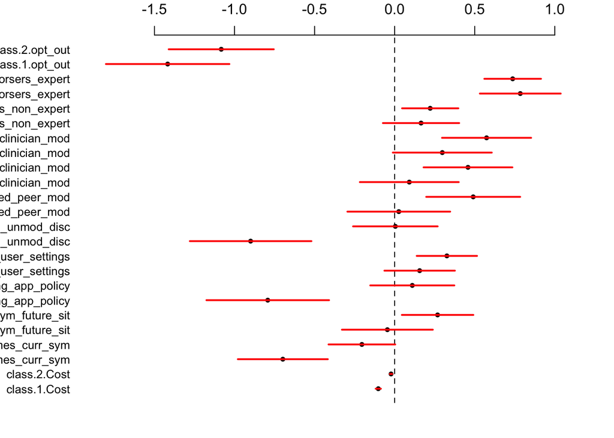

Figure 3.1: Cofficient variation by class in basic latent class model

Table 3.14: Mixed latent class model (estimated with gmnl package)

Parameter

est

se

stat

p

lwr

upr

sign

class.1.opt_out

-1.4674073

0.2025697

-7.2439613

0.0000000

-1.0703779

-1.8644366

***

class.1.Outcomes_curr_sym

-0.7134793

0.1463596

-4.8748381

0.0000011

-0.4266198

-1.0003388

***

class.1.Outcomes_curr_sym_future_sit

-0.0370828

0.1451875

-0.2554128

0.7984043

0.2474796

-0.3216451

n.s.

class.1.Information_sharing_app_policy

-0.8126520

0.2016632

-4.0297490

0.0000558

-0.4173994

-1.2079046

***

class.1.Information_sharing_user_settings

0.1640446

0.1145805

1.4316982

0.1522302

0.3886182

-0.0605289

n.s.

class.1.Social_unmod_disc

-0.9332417

0.1976830

-4.7208995

0.0000023

-0.5457901

-1.3206934

***

class.1.Social_trained_peer_mod

0.0405209

0.1658145

0.2443747

0.8069407

0.3655113

-0.2844696

n.s.

class.1.Social_clinician_mod

0.0906473

0.1628891

0.5564972

0.5778710

0.4099041

-0.2286095

n.s.

class.1.Social_peer_clinician_mod

0.3062542

0.1613108

1.8985353

0.0576256

0.6224175

-0.0099091

.

class.1.Endorsers_non_expert

0.1763680

0.1231276

1.4324005

0.1520292

0.4176936

-0.0649576

n.s.

class.1.Endorsers_expert

0.7968390

0.1297651

6.1406269

0.0000000

1.0511739

0.5425041

***

class.1.Cost

-0.1028362

0.0097238

-10.5757127

0.0000000

-0.0837779

-0.1218945

***

class.2.opt_out

-1.0723476

0.1655654

-6.4768822

0.0000000

-0.7478453

-1.3968498

***

class.2.Outcomes_curr_sym

-0.2000045

0.1054997

-1.8957830

0.0579887

0.0067711

-0.4067801

.

class.2.Outcomes_curr_sym_future_sit

0.2720039

0.1128697

2.4098929

0.0159572

0.4932244

0.0507833

class.2.Information_sharing_app_policy

0.1173688

0.1340561

0.8755201

0.3812910

0.3801138

-0.1453763

n.s.

class.2.Information_sharing_user_settings

0.3253134

0.0965778

3.3684081

0.0007560

0.5146024

0.1360244

***

class.2.Social_unmod_disc

0.0051815

0.1349981

0.0383823

0.9693829

0.2697730

-0.2594100

n.s.

class.2.Social_trained_peer_mod

0.4903084

0.1487029

3.2972350

0.0009764

0.7817608

0.1988561

***

class.2.Social_clinician_mod

0.4646432

0.1402173

3.3137369

0.0009206

0.7394640

0.1898224

***

class.2.Social_peer_clinician_mod

0.5762682

0.1408945

4.0900699

0.0000431

0.8524163

0.3001201

***

class.2.Endorsers_non_expert

0.2186670

0.0894927

2.4434049

0.0145494

0.3940695

0.0432644

class.2.Endorsers_expert

0.7379999

0.0896627

8.2308418

0.0000000

0.9137356

0.5622641

***

class.2.Cost

-0.0226088

0.0043185

-5.2353170

0.0000002

-0.0141447

-0.0310729

***

(class)2

-0.2176248

0.2076117

-1.0482297

0.2945328

0.1892867

-0.6245363

n.s.

der_age_u20:class2

0.4184097

0.0836309

5.0030498

0.0000006

0.5823233

0.2544961

***

class2:der_gender_male

0.3389004

0.0844640

4.0123636

0.0000601

0.5044468

0.1733539

***

class2:der_gender_opnts

-0.5506199

0.2060684

-2.6720256

0.0075395

-0.1467334

-0.9545065

class2:der_SIAS_nr

-0.4930891

0.1550610

-3.1799676

0.0014729

-0.1891750

-0.7970032

class2:der_SIAS_sa

-0.2821464

0.1158953

-2.4344945

0.0149126

-0.0549958

-0.5092970

class2:der_urban

-0.4157006

0.1152845

-3.6058686

0.0003111

-0.1897472

-0.6416540

***

class2:der_STE_VIC

0.5084802

0.1021073

4.9798591

0.0000006

0.7086069

0.3083535

***

class2:der_STE_QLD

0.9610344

0.1564815

6.1415193

0.0000000

1.2677326

0.6543362

***

class2:der_STE_SA

-0.3911096

0.1622921

-2.4099122

0.0159564

-0.0730230

-0.7091963

class2:der_STE_WA

0.6446911

0.1537307

4.1936403

0.0000275

0.9459977

0.3433846

***

class2:der_STE_ACT

-0.8825642

0.3077191

-2.8680841

0.0041297

-0.2794459

-1.4856824

class2:der_STE_TAS

-1.3716448

0.4488900

-3.0556368

0.0022458

-0.4918366

-2.2514531

class2:der_SEIFA_Q1

0.4702736

0.1465565

3.2088215

0.0013328

0.7575190

0.1830282

class2:der_SEIFA_Q2

-0.3567983

0.1220462

-2.9234685

0.0034616

-0.1175921

-0.5960046

class2:der_SEIFA_Q4

-0.2902282

0.1070185

-2.7119439

0.0066890

-0.0804758

-0.4999807

class2:rc_pilot_participant

0.5208162

0.1230549

4.2323874

0.0000231

0.7619995

0.2796329

***

class2:der_under_ten_mins

0.3297175

0.0928839

3.5497822

0.0003855

0.5117666

0.1476685

***

Note:

Signif. codes: 0 ‘**’ 0.001 ‘**’ 0.01 ‘’ 0.05 ‘.’ 0.1 ‘ ’ 1

Table 3.15: Mixed latent class model (estimated with gmnl package)

| Statistic | Value |
| --- | --- |
| logLik | -2555.043 |
| AIC | 5194.087 |
| BIC | 5449.392 |
| N | 3225.000 |

Table 3.16: Mixed mixed with correlated random parameters (estimated with gmnl package)

Parameter

est

se

stat

p

lwr

upr

sign

class.1.opt_out

-1.6490707

0.1483045

-11.1194923

0.0000000

-1.3583992

-1.9397422

***

class.1.Outc_curr_sym

-0.3136985

0.1016959

-3.0846711

0.0020378

-0.1143781

-0.5130189

class.1.Outc_curr_sym_future_sit

0.1003483

0.1721123

0.5830393

0.5598668

0.4376823

-0.2369857

n.s.

class.1.Info_sh_app_policy

0.0384812

0.1340262

0.2871167

0.7740230

0.3011677

-0.2242054

n.s.

class.1.Info_sh_user_settings

0.5080870

0.1218718

4.1690274

0.0000306

0.7469514

0.2692226

***

class.1.Soc_unmod_disc

-0.2826266

0.1532713

-1.8439631

0.0651885

0.0177796

-0.5830329

.

class.1.Soc_trained_peer_mod

0.2444976

0.1549248

1.5781695

0.1145267

0.5481447

-0.0591494

n.s.

class.1.Soc_clinician_mod

-0.0425348

0.1545944

-0.2751383

0.7832100

0.2604646

-0.3455342

n.s.

class.1.Soc_peer_clinician_mod

0.5825249

0.1677602

3.4723660

0.0005159

0.9113290

0.2537209

***

class.1.End_non_expert

0.2201741

0.0775559

2.8389067

0.0045268

0.3721810

0.0681672

class.1.End_expert

0.6443625

0.1268223

5.0808316

0.0000004

0.8929296

0.3957955

***

class.1.Cost

-0.0809266

0.0086397

-9.3667850

0.0000000

-0.0639930

-0.0978602

***

class.2.opt_out

-0.5297242

0.7769248

-0.6818217

0.4953517

0.9930204

-2.0524688

n.s.

class.2.Outc_curr_sym

-0.4313409

0.2669321

-1.6159197

0.1061117

0.0918365

-0.9545182

n.s.

class.2.Outc_curr_sym_future_sit

0.7225314

0.6066094

1.1910983

0.2336150

1.9114638

-0.4664011

n.s.

class.2.Info_sh_app_policy

-0.0775526

0.5392750

-0.1438089

0.8856513

0.9794071

-1.1345122

n.s.

class.2.Info_sh_user_settings

0.4035837

0.3552000

1.1362153

0.2558665

1.0997629

-0.2925955

n.s.

class.2.Soc_unmod_disc

-0.4496603

0.8295014

-0.5420851

0.5877599

1.1761325

-2.0754531

n.s.

class.2.Soc_trained_peer_mod

0.7379707

0.4196161

1.7586808

0.0786317

1.5604031

-0.0844617

.

class.2.Soc_clinician_mod

1.2285783

0.6130287

2.0041121

0.0450581

2.4300925

0.0270641

class.2.Soc_peer_clinician_mod

1.0239907

0.7900927

1.2960387

0.1949621

2.5725438

-0.5245625

n.s.

class.2.End_non_expert

0.5940014

0.6706500

0.8857099

0.3757739

1.9084513

-0.7204485

n.s.

class.2.End_expert

1.3345211

0.5966108

2.2368371

0.0252970

2.5038568

0.1651855

class.2.Cost

-0.0608117

0.0347959

-1.7476696

0.0805213

0.0073870

-0.1290104

.

class.1.sd.Cost.Cost

0.1821926

NaN

NaN

NaN

NaN

NaN

NA

class.1.sd.Cost.Outc_curr_sym

0.4606722

0.1362990

3.3798645

0.0007252

0.7278133

0.1935310

***

class.1.sd.Cost.Outc_curr_sym_future_sit

0.1634208

0.1654249

0.9878851

0.3232089

0.4876475

-0.1608060

n.s.

class.1.sd.Cost.Info_sh_app_policy

-0.1440407

0.3148816

-0.4574442

0.6473518

0.4731158

-0.7611973

n.s.

class.1.sd.Cost.Info_sh_user_settings

-0.1578762

0.0876179

-1.8018715

0.0715656

0.0138517

-0.3296042

.

class.1.sd.Cost.Soc_unmod_disc

0.1971271

0.1959497

1.0060089

0.3144113

0.5811814

-0.1869272

n.s.

class.1.sd.Cost.Soc_trained_peer_mod

0.4608763

0.2719981

1.6944102

0.0901874

0.9939827

-0.0722301

.

class.1.sd.Cost.Soc_clinician_mod

-0.0874309

0.1983626

-0.4407633

0.6593844

0.3013526

-0.4762144

n.s.

class.1.sd.Cost.Soc_peer_clinician_mod

-0.2634610

0.1719507

-1.5321887

0.1254759

0.0735563

-0.6004782

n.s.

class.1.sd.Cost.End_non_expert

-0.1724557

0.3061046

-0.5633883

0.5731705

0.4274982

-0.7724097

n.s.

class.1.sd.Cost.End_expert

-0.4216362

0.1595160

-2.6432226

0.0082121

-0.1089907

-0.7342817

class.1.sd.Cost.opt_out

0.0250114

0.0061520

4.0656060

0.0000479

0.0370691

0.0129538

***

class.1.sd.Outc_curr_sym.Outc_curr_sym

0.2341481

0.1127362

2.0769564

0.0378056

0.4551069

0.0131893

class.1.sd.Outc_curr_sym.Outc_curr_sym_future_sit

0.0414375

0.1412467

0.2933699

0.7692394

0.3182760

-0.2354009

n.s.

class.1.sd.Outc_curr_sym.Info_sh_app_policy

0.5987534

0.1928387

3.1049449

0.0019031

0.9767103

0.2207966

class.1.sd.Outc_curr_sym.Info_sh_user_settings

-0.0712062

0.3051029

-0.2333844

0.8154629

0.5267844

-0.6691969

n.s.

class.1.sd.Outc_curr_sym.Soc_unmod_disc

0.6715461

0.2435857

2.7569198

0.0058349

1.1489652

0.1941270

class.1.sd.Outc_curr_sym.Soc_trained_peer_mod

1.0797278

0.1980871

5.4507729

0.0000001

1.4679713

0.6914842

***

class.1.sd.Outc_curr_sym.Soc_clinician_mod

0.6419942

0.1598672

4.0157968

0.0000592

0.9553281

0.3286602

***

class.1.sd.Outc_curr_sym.Soc_peer_clinician_mod

0.7955621

0.2044862

3.8905425

0.0001000

1.1963476

0.3947766

***

class.1.sd.Outc_curr_sym.End_non_expert

-0.0195405

0.1304814

-0.1497571

0.8809563

0.2361984

-0.2752794

n.s.

class.1.sd.Outc_curr_sym.End_expert

-0.1456094

0.1852953

-0.7858235

0.4319709

0.2175627

-0.5087814

n.s.

class.1.sd.Outc_curr_sym.opt_out

0.0144615

0.0064717

2.2345905

0.0254442

0.0271457

0.0017773

class.1.sd.Outc_curr_sym_future_sit.Outc_curr_sym_future_sit

0.1175721

0.1352423

0.8693440

0.3846590

0.3826421

-0.1474980

n.s.

class.1.sd.Outc_curr_sym_future_sit.Info_sh_app_policy

0.1600997

0.2621307

0.6107628

0.5413566

0.6738665

-0.3536671

n.s.

class.1.sd.Outc_curr_sym_future_sit.Info_sh_user_settings

-0.0881763

0.2627175

-0.3356318

0.7371485

0.4267405

-0.6030932

n.s.

class.1.sd.Outc_curr_sym_future_sit.Soc_unmod_disc

0.0285973

0.1313981

0.2176387

0.8277106

0.2861328

-0.2289381

n.s.

class.1.sd.Outc_curr_sym_future_sit.Soc_trained_peer_mod

0.5056273

0.2440853

2.0715186

0.0383104

0.9840257

0.0272288

class.1.sd.Outc_curr_sym_future_sit.Soc_clinician_mod

0.1692728

0.1525943

1.1092996

0.2673010

0.4683522

-0.1298065

n.s.

class.1.sd.Outc_curr_sym_future_sit.Soc_peer_clinician_mod

-0.0521480

0.1833323

-0.2844452

0.7760692

0.3071766

-0.4114726

n.s.

class.1.sd.Outc_curr_sym_future_sit.End_non_expert

-0.0292323

0.2530975

-0.1154982

0.9080503

0.4668297

-0.5252943

n.s.

class.1.sd.Outc_curr_sym_future_sit.End_expert

-0.0218355

0.1444316

-0.1511821

0.8798321

0.2612453

-0.3049163

n.s.

class.1.sd.Outc_curr_sym_future_sit.opt_out

0.0391279

0.0076877

5.0896662

0.0000004

0.0541955

0.0240602

***

class.1.sd.Info_sh_app_policy.Info_sh_app_policy

0.1228900

0.1837104

0.6689330

0.5035382

0.4829558

-0.2371759

n.s.

class.1.sd.Info_sh_app_policy.Info_sh_user_settings

0.3278842

0.0678704

4.8310378

0.0000014

0.4609077

0.1948608

***

class.1.sd.Info_sh_app_policy.Soc_unmod_disc

0.0146947

0.0687230

0.2138256

0.8306831

0.1493893

-0.1199998

n.s.

class.1.sd.Info_sh_app_policy.Soc_trained_peer_mod

0.1410610

0.2609515

0.5405643

0.5888080

0.6525165

-0.3703944

n.s.

class.1.sd.Info_sh_app_policy.Soc_clinician_mod

-0.4300125

0.2460546

-1.7476304

0.0805280

0.0522457

-0.9122706

.

class.1.sd.Info_sh_app_policy.Soc_peer_clinician_mod

-0.4592692

0.2194689

-2.0926385

0.0363814

-0.0291179

-0.8894204

class.1.sd.Info_sh_app_policy.End_non_expert

-0.3280526

0.1423134

-2.3051420

0.0211586

-0.0491235

-0.6069818

class.1.sd.Info_sh_app_policy.End_expert

-0.0260882

0.1504625

-0.1733864

0.8623477

0.2688129

-0.3209892

n.s.

class.1.sd.Info_sh_app_policy.opt_out

0.0138990

0.0057619

2.4122059

0.0158563

0.0251922

0.0026058

class.1.sd.Info_sh_user_settings.Info_sh_user_settings

-0.1248513

0.1684803

-0.7410438

0.4586669

0.2053640

-0.4550666

n.s.

class.1.sd.Info_sh_user_settings.Soc_unmod_disc

0.2521972

0.3516695

0.7171426

0.4732861

0.9414568

-0.4370624

n.s.

class.1.sd.Info_sh_user_settings.Soc_trained_peer_mod

0.6034609

0.1802796

3.3473602

0.0008159

0.9568025

0.2501193

***

class.1.sd.Info_sh_user_settings.Soc_clinician_mod

0.0465988

0.2843748

0.1638639

0.8698383

0.6039632

-0.5107657

n.s.

class.1.sd.Info_sh_user_settings.Soc_peer_clinician_mod

0.4020526

0.1845300

2.1787925

0.0293471

0.7637247

0.0403804

class.1.sd.Info_sh_user_settings.End_non_expert

-0.1553351

0.1431448

-1.0851609

0.2778504

0.1252235

-0.4358937

n.s.

class.1.sd.Info_sh_user_settings.End_expert

-0.1575471

0.3141158

-0.5015573

0.6159790

0.4581086

-0.7732028

n.s.

class.1.sd.Info_sh_user_settings.opt_out

0.0000194

0.0048460

0.0040021

0.9968068

0.0095173

-0.0094785

n.s.

class.1.sd.Soc_unmod_disc.Soc_unmod_disc

-0.2756476

0.3634576

-0.7584036

0.4482094

0.4367163

-0.9880114

n.s.

class.1.sd.Soc_unmod_disc.Soc_trained_peer_mod

0.0332034

0.2340281

0.1418779

0.8871765

0.4918901

-0.4254832

n.s.

class.1.sd.Soc_unmod_disc.Soc_clinician_mod

-0.5546868

0.3113729

-1.7814231

0.0748434

0.0555928

-1.1649665

.

class.1.sd.Soc_unmod_disc.Soc_peer_clinician_mod

-0.4651583

0.2898849

-1.6046307

0.1085751

0.1030058

-1.0333223

n.s.

class.1.sd.Soc_unmod_disc.End_non_expert

-0.1066540

0.3750888

-0.2843432

0.7761474

0.6285066

-0.8418145

n.s.

class.1.sd.Soc_unmod_disc.End_expert

-0.7662889

0.3580956

-2.1399002

0.0323628

-0.0644344

-1.4681434

class.1.sd.Soc_unmod_disc.opt_out

0.0465591

0.0110173

4.2260162

0.0000238

0.0681525

0.0249657

***

class.1.sd.Soc_trained_peer_mod.Soc_trained_peer_mod

0.0229529

0.2557908

0.0897333

0.9284992

0.5242936

-0.4783877

n.s.

class.1.sd.Soc_trained_peer_mod.Soc_clinician_mod

0.2286548

0.1634435

1.3989835

0.1618179

0.5489982

-0.0916886

n.s.

class.1.sd.Soc_trained_peer_mod.Soc_peer_clinician_mod

-0.2581436

0.1495468

-1.7261725

0.0843164

0.0349628

-0.5512500

.

class.1.sd.Soc_trained_peer_mod.End_non_expert

-0.0725006

0.1037970

-0.6984846

0.4848742

0.1309378

-0.2759390

n.s.

class.1.sd.Soc_trained_peer_mod.End_expert

-0.1351546

0.1197152

-1.1289673

0.2589116

0.0994830

-0.3697921

n.s.

class.1.sd.Soc_trained_peer_mod.opt_out

0.0547980

0.0061440

8.9189808

0.0000000

0.0668400

0.0427560

***

class.1.sd.Soc_clinician_mod.Soc_clinician_mod

-0.2624132

0.3301371

-0.7948612

0.4266943

0.3846437

-0.9094700

n.s.

class.1.sd.Soc_clinician_mod.Soc_peer_clinician_mod

-0.2842468

0.1646819

-1.7260359

0.0843410

0.0385237

-0.6070173

.

class.1.sd.Soc_clinician_mod.End_non_expert

-0.2176134

0.1433018

-1.5185666

0.1288716

0.0632531

-0.4984798

n.s.

class.1.sd.Soc_clinician_mod.End_expert

-0.2939843

0.3608019

-0.8148080

0.4151822

0.4131745

-1.0011431

n.s.

class.1.sd.Soc_clinician_mod.opt_out

0.0481325

0.0086949

5.5356967

0.0000000

0.0651742

0.0310907

***

class.1.sd.Soc_peer_clinician_mod.Soc_peer_clinician_mod

-0.3773388

0.3763308

-1.0026787

0.3160159

0.3602559

-1.1149336

n.s.

class.1.sd.Soc_peer_clinician_mod.End_non_expert

-0.3702112

0.2252200

-1.6437756

0.1002226

0.0712119

-0.8116343

n.s.

class.1.sd.Soc_peer_clinician_mod.End_expert

0.0614444

0.2552659

0.2407074

0.8097819

0.5617563

-0.4388675

n.s.

class.1.sd.Soc_peer_clinician_mod.opt_out

0.0192551

0.0042495

4.5311861

0.0000059

0.0275839

0.0109263

***

class.1.sd.End_non_expert.End_non_expert

-0.2092627

NaN

NaN

NaN

NaN

NaN

NA

class.1.sd.End_non_expert.End_expert

-0.2546772

0.3013620

-0.8450872

0.3980622

0.3359815

-0.8453359

n.s.

class.1.sd.End_non_expert.opt_out

0.0300249

0.0051785

5.7980386

0.0000000

0.0401744

0.0198753

***

class.1.sd.End_expert.End_expert

0.2051637

0.2621462

0.7826306

0.4338441

0.7189609

-0.3086335

n.s.

class.1.sd.End_expert.opt_out

0.0147829

0.0042820

3.4523031

0.0005558

0.0231755

0.0063902

***

class.1.sd.opt_out.opt_out

0.0290374

0.0049817

5.8287926

0.0000000

0.0388014

0.0192734

***

class.2.sd.Cost.Cost

0.6651248

0.8437620

0.7882848

0.4305301

2.3188679

-0.9886184

n.s.

class.2.sd.Cost.Outc_curr_sym

0.0890304

0.2972984

0.2994648

0.7645855

0.6717246

-0.4936638

n.s.

class.2.sd.Cost.Outc_curr_sym_future_sit

0.0327638

0.4226022

0.0775288

0.9382029

0.8610488

-0.7955212

n.s.

class.2.sd.Cost.Info_sh_app_policy

1.0137018

0.7273115

1.3937657

0.1633884

2.4392060

-0.4118025

n.s.

class.2.sd.Cost.Info_sh_user_settings

0.3448398

0.6657063

0.5180059

0.6044542

1.6496001

-0.9599206

n.s.

class.2.sd.Cost.Soc_unmod_disc

-0.3143152

0.6113431

-0.5141387

0.6071550

0.8838954

-1.5125257

n.s.

class.2.sd.Cost.Soc_trained_peer_mod

0.2535173

0.7334785

0.3456370

0.7296156

1.6911087

-1.1840741

n.s.

class.2.sd.Cost.Soc_clinician_mod

0.4914543

0.6398284

0.7681033

0.4424258

1.7454949

-0.7625863

n.s.

class.2.sd.Cost.Soc_peer_clinician_mod

0.3581689

0.5230197

0.6848096

0.4934641

1.3832687

-0.6669309

n.s.

class.2.sd.Cost.End_non_expert

0.1431803

0.2333528

0.6135788

0.5394937

0.6005433

-0.3141827

n.s.

class.2.sd.Cost.End_expert

0.5279354

0.2154879

2.4499538

0.0142875

0.9502840

0.1055869

class.2.sd.Cost.opt_out

0.1456084

0.0487890

2.9844527

0.0028409

0.2412331

0.0499838

class.2.sd.Outc_curr_sym.Outc_curr_sym

0.4045354

0.6373462

0.6347185

0.5256120

1.6537110

-0.8446402

n.s.

class.2.sd.Outc_curr_sym.Outc_curr_sym_future_sit

0.7072372

0.4896900

1.4442548

0.1486673

1.6670120

-0.2525376

n.s.

class.2.sd.Outc_curr_sym.Info_sh_app_policy

0.5351467

0.5763537

0.9285040

0.3531462

1.6647793

-0.5944858

n.s.

class.2.sd.Outc_curr_sym.Info_sh_user_settings

0.0809292

0.4551080

0.1778241

0.8588611

0.9729244

-0.8110661

n.s.

class.2.sd.Outc_curr_sym.Soc_unmod_disc

1.1275558

0.3312241

3.4042087

0.0006636

1.7767431

0.4783686

***

class.2.sd.Outc_curr_sym.Soc_trained_peer_mod

0.7432506

0.6846811

1.0855427

0.2776814

2.0852009

-0.5986998

n.s.

class.2.sd.Outc_curr_sym.Soc_clinician_mod

1.2505410

0.3572562

3.5004035

0.0004646

1.9507503

0.5503316

***

class.2.sd.Outc_curr_sym.Soc_peer_clinician_mod

0.5949166

0.5289071

1.1248036

0.2606722

1.6315554

-0.4417222

n.s.

class.2.sd.Outc_curr_sym.End_non_expert

-0.1512432

0.2463842

-0.6138512

0.5393136

0.3316609

-0.6341474

n.s.

class.2.sd.Outc_curr_sym.End_expert

-0.0829475

0.3820224

-0.2171273

0.8281092

0.6658026

-0.8316976

n.s.

class.2.sd.Outc_curr_sym.opt_out

0.1119607

0.0367974

3.0426221

0.0023453

0.1840824

0.0398390

class.2.sd.Outc_curr_sym_future_sit.Outc_curr_sym_future_sit

0.1453103

0.4506175

0.3224694

0.7470971

1.0285043

-0.7378837

n.s.

class.2.sd.Outc_curr_sym_future_sit.Info_sh_app_policy

1.1027489

0.5173357

2.1315926

0.0330404

2.1167081

0.0887896

class.2.sd.Outc_curr_sym_future_sit.Info_sh_user_settings

1.2331384

0.4166775

2.9594554

0.0030818

2.0498113

0.4164656

class.2.sd.Outc_curr_sym_future_sit.Soc_unmod_disc

0.4315124

0.5544057

0.7783332

0.4363726

1.5181277

-0.6551029

n.s.

class.2.sd.Outc_curr_sym_future_sit.Soc_trained_peer_mod

-0.6419154

0.3043021

-2.1094673

0.0349043

-0.0454942

-1.2383367

class.2.sd.Outc_curr_sym_future_sit.Soc_clinician_mod

-0.0579750

0.3608149

-0.1606780

0.8723470

0.6492091

-0.7651591

n.s.

class.2.sd.Outc_curr_sym_future_sit.Soc_peer_clinician_mod

0.0107076

0.4785758

0.0223739

0.9821497

0.9486989

-0.9272837

n.s.

class.2.sd.Outc_curr_sym_future_sit.End_non_expert

0.6663042

0.5107777

1.3044895

0.1920667

1.6674101

-0.3348018

n.s.

class.2.sd.Outc_curr_sym_future_sit.End_expert

-0.0401369

0.4793310

-0.0837354

0.9332668

0.8993345

-0.9796084

n.s.

class.2.sd.Outc_curr_sym_future_sit.opt_out

0.1520587

0.0464124

3.2762492

0.0010520

0.2430254

0.0610920

class.2.sd.Info_sh_app_policy.Info_sh_app_policy

1.4642323

0.1458733

10.0376987

0.0000000

1.7501387

1.1783258

***

class.2.sd.Info_sh_app_policy.Info_sh_user_settings

0.9775898

0.1453738

6.7246639

0.0000000

1.2625171

0.6926624

***

class.2.sd.Info_sh_app_policy.Soc_unmod_disc

0.2813534

NaN

NaN

NaN

NaN

NaN

NA

class.2.sd.Info_sh_app_policy.Soc_trained_peer_mod

0.8926083

0.6718727

1.3285379

0.1840005

2.2094545

-0.4242379

n.s.

class.2.sd.Info_sh_app_policy.Soc_clinician_mod

0.7302737

0.5240660

1.3934767

0.1634757

1.7574242

-0.2968767

n.s.

class.2.sd.Info_sh_app_policy.Soc_peer_clinician_mod

1.0564813

0.4815437

2.1939470

0.0282392

2.0002896

0.1126730

class.2.sd.Info_sh_app_policy.End_non_expert

0.0692043

0.7613664

0.0908948

0.9275762

1.5614550

-1.4230465

n.s.

class.2.sd.Info_sh_app_policy.End_expert

-0.7026947

0.7215475

-0.9738718

0.3301202

0.7115123

-2.1169017

n.s.

class.2.sd.Info_sh_app_policy.opt_out

0.1392049

0.0592257

2.3504122

0.0187526

0.2552852

0.0231246

class.2.sd.Info_sh_user_settings.Info_sh_user_settings

0.5398669

0.3166312

1.7050337

0.0881881

1.1604527

-0.0807189

.

class.2.sd.Info_sh_user_settings.Soc_unmod_disc

0.4460452

0.5848173

0.7627087

0.4456371

1.5922661

-0.7001756

n.s.

class.2.sd.Info_sh_user_settings.Soc_trained_peer_mod

-0.2699447

0.4573776

-0.5902009

0.5550560

0.6264990

-1.1663884

n.s.

class.2.sd.Info_sh_user_settings.Soc_clinician_mod

0.4823203

0.2545854

1.8945323

0.0581544

0.9812985

-0.0166580

.

class.2.sd.Info_sh_user_settings.Soc_peer_clinician_mod

0.3064295

0.4113578

0.7449219

0.4563189

1.1126760

-0.4998171

n.s.

class.2.sd.Info_sh_user_settings.End_non_expert

0.7524449

0.3274107

2.2981679

0.0215522

1.3941581

0.1107316

class.2.sd.Info_sh_user_settings.End_expert

-0.1027362

0.3583309

-0.2867075

0.7743363

0.5995795

-0.8050519

n.s.

class.2.sd.Info_sh_user_settings.opt_out

0.1583431

0.0504349

3.1395536

0.0016921

0.2571936

0.0594925

class.2.sd.Soc_unmod_disc.Soc_unmod_disc

0.7915872

0.3360582

2.3555063

0.0184975

1.4502491

0.1329252

class.2.sd.Soc_unmod_disc.Soc_trained_peer_mod

-0.1158172

0.4000208

-0.2895281

0.7721773

0.6682091

-0.8998436

n.s.

class.2.sd.Soc_unmod_disc.Soc_clinician_mod

0.0452543

0.4957608

0.0912826

0.9272681

1.0169276

-0.9264189

n.s.

class.2.sd.Soc_unmod_disc.Soc_peer_clinician_mod

0.1924368

0.4333642

0.4440532

0.6570041

1.0418151

-0.6569415

n.s.

class.2.sd.Soc_unmod_disc.End_non_expert

0.0701482

0.4144943

0.1692379

0.8656095

0.8825421

-0.7422458

n.s.

class.2.sd.Soc_unmod_disc.End_expert

0.7806226

0.4592491

1.6997801

0.0891723

1.6807344

-0.1194892

.

class.2.sd.Soc_unmod_disc.opt_out

0.1613758

0.0653507

2.4693793

0.0135348

0.2894609

0.0332907

class.2.sd.Soc_trained_peer_mod.Soc_trained_peer_mod

-0.4012353

0.6634257

-0.6047930

0.5453165

0.8990553

-1.7015258

n.s.

class.2.sd.Soc_trained_peer_mod.Soc_clinician_mod

0.0162514

0.4263391

0.0381185

0.9695932

0.8518606

-0.8193578

n.s.

class.2.sd.Soc_trained_peer_mod.Soc_peer_clinician_mod

0.5418034

0.3775182

1.4351718

0.1512382

1.2817255

-0.1981186

n.s.

class.2.sd.Soc_trained_peer_mod.End_non_expert

-0.0096341

0.4506629

-0.0213776

0.9829445

0.8736490

-0.8929171

n.s.

class.2.sd.Soc_trained_peer_mod.End_expert

0.3706088

0.3677589

1.0077494

0.3135748

1.0914030

-0.3501854

n.s.

class.2.sd.Soc_trained_peer_mod.opt_out

0.1690951

0.0486697

3.4743372

0.0005121

0.2644861

0.0737042

***

class.2.sd.Soc_clinician_mod.Soc_clinician_mod

0.6855128

0.8177125

0.8383299

0.4018455

2.2881999

-0.9171742

n.s.

class.2.sd.Soc_clinician_mod.Soc_peer_clinician_mod

0.5580904

0.7578330

0.7364293

0.4614695

2.0434159

-0.9272350

n.s.

class.2.sd.Soc_clinician_mod.End_non_expert

0.1239287

0.4182637

0.2962933

0.7670061

0.9437105

-0.6958531

n.s.

class.2.sd.Soc_clinician_mod.End_expert

-0.4984099

0.3225367

-1.5452812

0.1222783

0.1337504

-1.1305703

n.s.

class.2.sd.Soc_clinician_mod.opt_out

0.1678819

0.0622853

2.6953681

0.0070311

0.2899588

0.0458049

class.2.sd.Soc_peer_clinician_mod.Soc_peer_clinician_mod

0.5457497

0.5432074

1.0046801

0.3150509

1.6104167

-0.5189173

n.s.

class.2.sd.Soc_peer_clinician_mod.End_non_expert

-0.2347075

0.4271970

-0.5494127

0.5827223

0.6025833

-1.0719983

n.s.

class.2.sd.Soc_peer_clinician_mod.End_expert

0.2736449

0.5444216

0.5026341

0.6152215

1.3406916

-0.7934019

n.s.

class.2.sd.Soc_peer_clinician_mod.opt_out

0.1550782

0.0643538

2.4097749

0.0159624

0.2812093

0.0289470

class.2.sd.End_non_expert.End_non_expert

0.6906396

0.2445989

2.8235594

0.0047494

1.1700447

0.2112345

class.2.sd.End_non_expert.End_expert

0.0423271

0.6712590

0.0630563

0.9497217

1.3579705

-1.2733163

n.s.

class.2.sd.End_non_expert.opt_out

0.1281159

0.0414750

3.0889881

0.0020084

0.2094055

0.0468263

class.2.sd.End_expert.End_expert

-0.5121666

0.3336065

-1.5352416

0.1247245

0.1416902

-1.1660233

n.s.

class.2.sd.End_expert.opt_out

0.1627856

0.0547430

2.9736323

0.0029430

0.2700800

0.0554913

class.2.sd.opt_out.opt_out

0.1580450

0.0662243

2.3865090

0.0170092

0.2878423

0.0282477

(class)2

-1.5995688

0.4913030

-3.2557685

0.0011309

-0.6366326

-2.5625050

der_age_u20:class2

-1.0158016

0.2299009

-4.4184316

0.0000099

-0.5652040

-1.4663991

***

class2:der_gender_male

-0.1294288

0.2323384

-0.5570704

0.5774793

0.3259460

-0.5848037

n.s.

class2:der_gender_opnts

-2.2979518

1.4830755

-1.5494504

0.1212735

0.6088227

-5.2047263

n.s.

class2:der_SIAS_nr

1.7854344

0.4728808

3.7756542

0.0001596

2.7122637

0.8586050

***

class2:der_SIAS_sa

1.5628904

0.4272079

3.6583834

0.0002538

2.4002026

0.7255783

***

class2:der_urban

-0.3697952

0.2367543

-1.5619369

0.1183028

0.0942346

-0.8338250

n.s.

class2:der_STE_VIC

-0.7020412

0.4391720

-1.5985562

0.1099192

0.1587202

-1.5628026

n.s.

class2:der_STE_QLD

-0.4039295

0.3868527

-1.0441428

0.2964193

0.3542879

-1.1621468

n.s.

class2:der_STE_SA

-1.2298922

0.6930755

-1.7745427

0.0759734

0.1285110

-2.5882953

.

class2:der_STE_WA

-0.6556362

0.2707839

-2.4212526

0.0154671

-0.1249095

-1.1863629

class2:der_STE_ACT

-3.3583977

NaN

NaN

NaN

NaN

NaN

NA

class2:der_STE_TAS

1.2828969

0.4218437

3.0411666

0.0023566

2.1096953

0.4560985

class2:der_SEIFA_Q1

-1.9485571

0.2144876

-9.0847077

0.0000000

-1.5281691

-2.3689451

***

class2:der_SEIFA_Q2

-1.5375471

0.4532903

-3.3919698

0.0006939

-0.6491144

-2.4259798

***

class2:der_SEIFA_Q4

-0.7073899

0.2844159

-2.4871676

0.0128765

-0.1499451

-1.2648348

class2:rc_pilot_participant

0.2028772

0.3024392

0.6708032

0.5023459

0.7956471

-0.3898927

n.s.

class2:der_under_ten_mins

0.5457698

0.2007045

2.7192699

0.0065426

0.9391435

0.1523962

Note:

Signif. codes: 0 ‘**’ 0.001 ‘**’ 0.01 ‘’ 0.05 ‘.’ 0.1 ‘ ’ 1

Table 3.17: Mixed mixed with correlated random parameters (estimated with gmnl package)

| Statistic | Value |
| --- | --- |
| logLik | -2507.159 |
| AIC | 5410.317 |
| BIC | 6613.898 |
| N | 3225.000 |

# 4 Applying choice models

## 4.1 Generating Willingness To Pay Estimates

### 4.1.1 Willingness To Pay Estimates from Utility Space

We can use the output of the Multinomial Logit Model we estimated to calculate Willingness To Pay values from utility space.

Table 4.1: Willingness to pay estimated from utility space using multinomial logit model (estimated with gmnl package)

| Parameter | Estimate | Std. Error | t-value | Pr(>\|t\|) | sign |
| --- | --- | --- | --- | --- | --- |
| opt_out | -21.063399 | 2.696931 | 7.810137 | 0.0000000 | *** |
| Outcomes_curr_sym | -6.903538 | 1.703917 | 4.051570 | 0.0000509 | *** |
| Outcomes_curr_sym_future_sit | 5.338594 | 1.503190 | -3.551511 | 0.0003830 | *** |
| Information_sharing_app_policy | -1.607790 | 1.937362 | 0.829886 | 0.4066032 | n.s. |
| Information_sharing_user_settings | 5.724191 | 1.391826 | -4.112720 | 0.0000391 | *** |
| Social_unmod_disc | -6.263271 | 2.280858 | 2.746015 | 0.0060324 | ** |
| Social_trained_peer_mod | 7.046178 | 2.042073 | -3.450503 | 0.0005595 | *** |
| Social_clinician_mod | 6.670704 | 1.977217 | -3.373784 | 0.0007414 | *** |
| Social_peer_clinician_mod | 11.779540 | 1.941916 | -6.065936 | 0.0000000 | *** |
| Endorsers_non_expert | 5.741062 | 1.512820 | -3.794940 | 0.0001477 | *** |
| Endorsers_expert | 15.998268 | 1.400063 | -11.426822 | 0.0000000 | *** |

Note:  
Signif. codes: 0 ‘**’ 0.001 ‘**’ 0.01 ‘’ 0.05 ‘.’ 0.1 ‘ ’ 1

### 4.1.2 Willingness To Pay Estimates from WTP Space

Alternatively we can use the Scaled Multinomial Logit Model to calculate Willingness to Pay Values from Willingness To Pay space.

Table 4.2: Willingness to pay estimated from willingness to pay space using a scaled multinomial logit model (estimated with gmnl package)

| Parameter | Estimate | Std. Error | z-value | Pr(>\|z\|) | sign |
| --- | --- | --- | --- | --- | --- |
| opt_out | -21.063880 | 2.7649288 | -7.6182360 | 0.0000000 | *** |
| Outcomes_curr_sym | -6.903880 | 1.7410062 | -3.9654541 | 0.0000733 | *** |
| Outcomes_curr_sym_future_sit | 5.337832 | 1.5053232 | 3.5459709 | 0.0003912 | *** |
| Information_sharing_app_policy | -1.608555 | 1.9447278 | -0.8271361 | 0.4081599 | n.s. |
| Information_sharing_user_settings | 5.724088 | 1.4012893 | 4.0848723 | 0.0000441 | *** |
| Social_unmod_disc | -6.263351 | 2.3025342 | -2.7201989 | 0.0065243 | ** |
| Social_trained_peer_mod | 7.045781 | 2.1081270 | 3.3421996 | 0.0008312 | *** |
| Social_clinician_mod | 6.670416 | 2.0328516 | 3.2813100 | 0.0010333 | ** |
| Social_peer_clinician_mod | 11.778776 | 1.9382075 | 6.0771495 | 0.0000000 | *** |
| Endorsers_non_expert | 5.740878 | 1.5111403 | 3.7990370 | 0.0001453 | *** |
| Endorsers_expert | 15.997951 | 1.3948278 | 11.4694806 | 0.0000000 | *** |
| het.(Intercept) | -3.135348 | 0.0442928 | -70.7869091 | 0.0000000 | *** |

Note:  
Signif. codes: 0 ‘**’ 0.001 ‘**’ 0.01 ‘’ 0.05 ‘.’ 0.1 ‘ ’ 1

### 4.1.3 Willingness To Pay Heterogeneity

We can also explore how WTP values vary across individuals.

Table 4.3: Willingness to pay estimated from generalised multinomial logit model with correlated random parameters (estimated with gmnl package)

Parameter

est

se

stat

p

lwr

upr

sign

opt_out

-24.1018400

1.8049932

-13.3528699

0.0000000

-20.5641182

-27.6395617

***

Outc_curr_sym

-3.8150193

1.2711358

-3.0012682

0.0026886

-1.3236390

-6.3063996

Outc_curr_sym_future_sit

4.9300912

1.0935924

4.5081616

0.0000065

7.0734930

2.7866895

***

Info_sh_app_policy

1.5420310

1.5996784

0.9639631

0.3350644

4.6773431

-1.5932811

n.s.

Info_sh_user_settings

5.5577167

0.9204283

6.0381856

0.0000000

7.3617230

3.7537105

***

Soc_unmod_disc

-2.0045928

1.5994388

-1.2533101

0.2100929

1.1302496

-5.1394353

n.s.

Soc_trained_peer_mod

7.1855258

1.2352256

5.8171771

0.0000000

9.6065234

4.7645282

***

Soc_clinician_mod

6.8333145

1.1599069

5.8912611

0.0000000

9.1066903

4.5599387

***

Soc_peer_clinician_mod

9.6166130

1.1086289

8.6743298

0.0000000

11.7894858

7.4437402

***

End_non_expert

5.4294157

0.9539921

5.6912583

0.0000000

7.2992060

3.5596255

***

End_expert

13.6912867

1.0313950

13.2745327

0.0000000

15.7127837

11.6697896

***

het.(Intercept)

-1.8813757

0.1106492

-17.0030619

0.0000000

-1.6645072

-2.0982442

***

sd.Outc_curr_sym.Outc_curr_sym

-11.4701786

1.9431756

-5.9028007

0.0000000

-7.6616243

-15.2787329

***

sd.Outc_curr_sym.Outc_curr_sym_future_sit

8.6611109

1.1106387

7.7983154

0.0000000

10.8379228

6.4842990

***

sd.Outc_curr_sym.Info_sh_app_policy

8.2040852

1.1190849

7.3310659

0.0000000

10.3974513

6.0107191

***

sd.Outc_curr_sym.Info_sh_user_settings

12.8027561

1.3929858

9.1908736

0.0000000

15.5329581

10.0725542

***

sd.Outc_curr_sym.Soc_unmod_disc

3.2124361

0.9099023

3.5305287

0.0004147

4.9958117

1.4290604

***

sd.Outc_curr_sym.Soc_trained_peer_mod

11.3894748

1.3431910

8.4794158

0.0000000

14.0220807

8.7568688

***

sd.Outc_curr_sym.Soc_clinician_mod

10.6488617

1.2561937

8.4770859

0.0000000

13.1109560

8.1867673

***

sd.Outc_curr_sym.Soc_peer_clinician_mod

10.3078229

1.3094386

7.8719405

0.0000000

12.8742755

7.7413704

***

sd.Outc_curr_sym.End_non_expert

7.7732943

1.1942273

6.5090578

0.0000000

10.1139367

5.4326519

***

sd.Outc_curr_sym.End_expert

0.0044559

1.0506018

0.0042413

0.9966160

2.0635976

-2.0546859

n.s.

sd.Outc_curr_sym.opt_out

-1.7678265

1.1356599

-1.5566514

0.1195533

0.4580259

-3.9936789

n.s.

sd.Outc_curr_sym_future_sit.Outc_curr_sym_future_sit

0.2464574

1.1006518

0.2239195

0.8228200

2.4036952

-1.9107804

n.s.

sd.Outc_curr_sym_future_sit.Info_sh_app_policy

-0.1309451

1.0078657

-0.1299232

0.8966272

1.8444353

-2.1063255

n.s.

sd.Outc_curr_sym_future_sit.Info_sh_user_settings

6.8471858

1.2820164

5.3409501

0.0000001

9.3598918

4.3344797

***

sd.Outc_curr_sym_future_sit.Soc_unmod_disc

7.4472070

1.0672048

6.9782361

0.0000000

9.5388899

5.3555240

***

sd.Outc_curr_sym_future_sit.Soc_trained_peer_mod

-2.3941093

1.2915534

-1.8536665

0.0637869

0.1372888

-4.9255073

.

sd.Outc_curr_sym_future_sit.Soc_clinician_mod

1.8561470

1.0392659

1.7860174

0.0740964

3.8930708

-0.1807768

.

sd.Outc_curr_sym_future_sit.Soc_peer_clinician_mod

-1.5978637

1.1993853

-1.3322356

0.1827828

0.7528883

-3.9486157

n.s.

sd.Outc_curr_sym_future_sit.End_non_expert

0.9733270

1.1321628

0.8597059

0.3899512

3.1923254

-1.2456713

n.s.

sd.Outc_curr_sym_future_sit.End_expert

2.6276684

0.9589376

2.7401870

0.0061404

4.5071515

0.7481852

sd.Outc_curr_sym_future_sit.opt_out

1.9159470

0.9130291

2.0984511

0.0358653

3.7054512

0.1264428

sd.Info_sh_app_policy.Info_sh_app_policy

3.2555275

0.9327691

3.4901751

0.0004827

5.0837213

1.4273337

***

sd.Info_sh_app_policy.Info_sh_user_settings

6.3827416

1.3266401

4.8112080

0.0000015

8.9829085

3.7825748

***

sd.Info_sh_app_policy.Soc_unmod_disc

5.2971929

0.8624723

6.1418703

0.0000000

6.9876075

3.6067783

***

sd.Info_sh_app_policy.Soc_trained_peer_mod

-0.9837160

1.3129165

-0.7492602

0.4537004

1.5895530

-3.5569849

n.s.

sd.Info_sh_app_policy.Soc_clinician_mod

0.1007585

0.9764628

0.1031873

0.9178143

2.0145904

-1.8130733

n.s.

sd.Info_sh_app_policy.Soc_peer_clinician_mod

0.1391275

1.2484135

0.1114435

0.9112647

2.5859730

-2.3077179

n.s.

sd.Info_sh_app_policy.End_non_expert

1.1914774

1.1918180

0.9997142

0.3174488

3.5273977

-1.1444429

n.s.

sd.Info_sh_app_policy.End_expert

-3.9707001

1.1190273

-3.5483496

0.0003877

-1.7774469

-6.1639533

***

sd.Info_sh_app_policy.opt_out

-0.1675892

0.8688047

-0.1928962

0.8470402

1.5352368

-1.8704151

n.s.

sd.Info_sh_user_settings.Info_sh_user_settings

8.2205049

1.2983218

6.3316388

0.0000000

10.7651689

5.6758408

***

sd.Info_sh_user_settings.Soc_unmod_disc

1.8084248

1.1427120

1.5825726

0.1135189

4.0480992

-0.4312496

n.s.

sd.Info_sh_user_settings.Soc_trained_peer_mod

1.8710195

1.9261723

0.9713666

0.3313657

5.6462478

-1.9042088

n.s.

sd.Info_sh_user_settings.Soc_clinician_mod

0.0574114

1.2745767

0.0450435

0.9640727

2.5555358

-2.4407131

n.s.

sd.Info_sh_user_settings.Soc_peer_clinician_mod

-1.7112277

1.5273743

-1.1203722

0.2625552

1.2823710

-4.7048264

n.s.

sd.Info_sh_user_settings.End_non_expert

0.9408668

1.2355360

0.7615050

0.4463555

3.3624728

-1.4807392

n.s.

sd.Info_sh_user_settings.End_expert

1.2306000

1.1239048

1.0949326

0.2735462

3.4334128

-0.9722129

n.s.

sd.Info_sh_user_settings.opt_out

2.8855241

1.1402640

2.5305754

0.0113876

5.1204006

0.6506477

sd.Soc_unmod_disc.Soc_unmod_disc

1.7012498

0.9450009

1.8002625

0.0718192

3.5534176

-0.1509180

.

sd.Soc_unmod_disc.Soc_trained_peer_mod

8.8728573

1.3201746

6.7209725

0.0000000

11.4603520

6.2853626

***

sd.Soc_unmod_disc.Soc_clinician_mod

5.6907972

1.2212599

4.6597758

0.0000032

8.0844226

3.2971718

***

sd.Soc_unmod_disc.Soc_peer_clinician_mod

2.8067253

1.2949020

2.1675195

0.0301953

5.3446865

0.2687641

sd.Soc_unmod_disc.End_non_expert

6.5118036

1.3846212

4.7029496

0.0000026

9.2256113

3.7979960

***

sd.Soc_unmod_disc.End_expert

-1.6625163

1.1091764

-1.4988746

0.1339062

0.5114294

-3.8364620

n.s.

sd.Soc_unmod_disc.opt_out

1.3208230

1.0945175

1.2067628

0.2275235

3.4660379

-0.8243919

n.s.

sd.Soc_trained_peer_mod.Soc_trained_peer_mod

-1.6409831

1.2019669

-1.3652481

0.1721751

0.7148288

-3.9967950

n.s.

sd.Soc_trained_peer_mod.Soc_clinician_mod

-1.6681348

0.9434904

-1.7680464

0.0770532

0.1810724

-3.5173421

.

sd.Soc_trained_peer_mod.Soc_peer_clinician_mod

0.0058331

0.8441545

0.0069100

0.9944866

1.6603456

-1.6486793

n.s.

sd.Soc_trained_peer_mod.End_non_expert

-1.2717652

0.9500206

-1.3386711

0.1806778

0.5902411

-3.1337714

n.s.

sd.Soc_trained_peer_mod.End_expert

3.7634408

0.9298950

4.0471675

0.0000518

5.5860015

1.9408801

***

sd.Soc_trained_peer_mod.opt_out

4.0618987

1.1699955

3.4717215

0.0005171

6.3550478

1.7687496

***

sd.Soc_clinician_mod.Soc_clinician_mod

-0.5745918

1.2410513

-0.4629880

0.6433730

1.8578240

-3.0070076

n.s.

sd.Soc_clinician_mod.Soc_peer_clinician_mod

-3.1655611

1.3616070

-2.3248714

0.0200788

-0.4968605

-5.8342617

sd.Soc_clinician_mod.End_non_expert

-3.5862047

1.1926611

-3.0068934

0.0026393

-1.2486320

-5.9237775

sd.Soc_clinician_mod.End_expert

-0.1083901

1.0436778

-0.1038540

0.9172852

1.9371807

-2.1539610

n.s.

sd.Soc_clinician_mod.opt_out

-4.7581658

1.1321490

-4.2027736

0.0000264

-2.5391946

-6.9771369

***

sd.Soc_peer_clinician_mod.Soc_peer_clinician_mod

-0.2001764

1.0341130

-0.1935731

0.8465102

1.8266477

-2.2270006

n.s.

sd.Soc_peer_clinician_mod.End_non_expert

-0.9639443

1.2846025

-0.7503833

0.4530239

1.5538303

-3.4817190

n.s.

sd.Soc_peer_clinician_mod.End_expert

5.3103170

0.9965872

5.3285024

0.0000001

7.2635919

3.3570421

***

sd.Soc_peer_clinician_mod.opt_out

2.6574454

0.8243623

3.2236377

0.0012657

4.2731658

1.0417250

sd.End_non_expert.End_non_expert

0.1349603

0.9870978

0.1367243

0.8912487

2.0696364

-1.7997158

n.s.

sd.End_non_expert.End_expert

-1.2427943

0.8857683

-1.4030692

0.1605962

0.4932798

-2.9788683

n.s.

sd.End_non_expert.opt_out

0.2035629

1.1908719

0.1709360

0.8642741

2.5376288

-2.1305031

n.s.

sd.End_expert.End_expert

-0.4041969

0.7704768

-0.5246062

0.5998570

1.1059098

-1.9143036

n.s.

sd.End_expert.opt_out

3.0856237

0.8986608

3.4335798

0.0005957

4.8469666

1.3242808

***

sd.opt_out.opt_out

-4.8409905

1.2003045

-4.0331354

0.0000550

-2.4884369

-7.1935441

***

tau

1.0848823

0.0825750

13.1381464

0.0000000

1.2467263

0.9230383

***

Note:

Signif. codes: 0 ‘**’ 0.001 ‘**’ 0.01 ‘’ 0.05 ‘.’ 0.1 ‘ ’ 1

## 4.2 Predicting Market Share

### 4.2.1 Market share predictions using the same choice situations as that used in the original survey

Table 4.4: Market share predictions from multinomial logit models compared to observed sample proportions

| Alternative | Predictions (MNL model, gmnl package) | Predictions (MNL model, mlogit package) | Observed |
| --- | --- | --- | --- |
| Social Anxiety App A | 0.3469779 | 0.3247964 | 0.3586420 |
| Social Anxiety App B | 0.4391332 | 0.4656007 | 0.4274691 |
| Do not use a social anxiety app | 0.2138889 | 0.2096029 | 0.2138889 |

Table 4.5: Market share predictions from mixed logit models (estimated with gmnl package)

| Alternative | Mean | SD |
| --- | --- | --- |
| Social Anxiety App A | 0.3669715 | 0.2178513 |
| Social Anxiety App B | 0.4200165 | 0.2142072 |
| Do not use a social anxiety app | 0.2130120 | 0.1733450 |

Table 4.6: Market share predictions from mixed logit models (estimated with mlogit package)

| Alternative | Mean | SD |
| --- | --- | --- |
| Social Anxiety App A | 0.3764415 | 0.1925379 |
| Social Anxiety App B | 0.4055234 | 0.1883529 |
| Do not use a social anxiety app | 0.2180350 | 0.1631860 |

### 4.2.2 Market share predictions using new choice situations

We created a hypothetical choice situation where: - the Entourage app had a $25 cost, was endorsed by experts, had both peer and clinician moderators, provided knowledge and skills to manage future situations and shared no information with app users’ treating clinicians; and - a competing app had a $0 cost, had no endorsers, had no discussions with other app users, provided knowledge and skills to manage future situations and shared no information with app users’ treating clinicians.

The market share predictions from both a multinomial model and mixed logit model for each app under this choice situation is summarised in the following table.

Table 4.7: Market share predictions from multinomial and mixed logit models (both estimated with mlogit package) of hypotetical choice situation one

| Alternative | mnl_mlogit_mdl_prediction | mixl_mlogit_mdl_prediction |
| --- | --- | --- |
| Entourage | 0.4462611 | 0.3552592 |
| Competing App | 0.3954856 | 0.4546048 |
| No App | 0.1582533 | 0.1901360 |

We then changed the configuration of the Entourage app by adding a user controlled setting for app information sharing. The market share predictions under this modified scenario are summarised in the next table.

Table 4.8: Market share predictions from multinomial and mixed logit models (both estimated with mlogit package) of hypotetical choice situation two

| Alternative | mnl_mlogit_mdl_prediction | mixl_mlogit_mdl_prediction |
| --- | --- | --- |
| Entourage | 0.5082794 | 0.4018983 |
| Competing App | 0.3511915 | 0.4506653 |
| No App | 0.1405291 | 0.1474364 |

We reran the first hypothetical choice situation adjusting the price between $25 and $50.

Table 4.9: Market share predictions from multimomial logit models (estimated with mlogit package) of hypotetical choice situation three

| Cost | Entourage | Competing App | No App |
| --- | --- | --- | --- |
| 25 | 0.4462611 | 0.3954856 | 0.1582533 |
| 30 | 0.3933605 | 0.4332677 | 0.1733718 |
| 35 | 0.3428481 | 0.4693441 | 0.1878077 |
| 40 | 0.2956609 | 0.5030457 | 0.2012934 |
| 45 | 0.2524730 | 0.5338909 | 0.2136361 |
| 50 | 0.2136799 | 0.5615973 | 0.2247228 |

Table 4.10: Market share predictions from mixed logit models (estimated with mlogit package) of hypotetical choice situation three

| Cost | Entourage | Competing App | No App |
| --- | --- | --- | --- |
| 25 | 0.3552592 | 0.4546048 | 0.1901360 |
| 30 | 0.3330646 | 0.4658380 | 0.2010974 |
| 35 | 0.3171806 | 0.4736067 | 0.2092127 |
| 40 | 0.3054732 | 0.4791791 | 0.2153477 |
| 45 | 0.2965875 | 0.4833188 | 0.2200937 |
| 50 | 0.2896663 | 0.4864848 | 0.2238489 |